# Bridging Study（桥接研究）与 Follow-on CDx（后续伴随诊断）：概念、公式与全流程 worked example

胡杨博士

首次发布：2026-08-25 | 最后更新：2026-09-28 16:39 EDT

> 本文定位：bridging study（桥接研究）与 follow-on CDx（follow-on companion diagnostic，后续伴随诊断）统计方法的学习笔记。前两章先铺背景——精准医学与传统医学有何不同、为什么要”搬运证据”（概念框架），以及 CDx 试验怎么设计（入组、对照、设盲三个取舍）；有了背景再进入方法。方法部分分两条腿走：概念 讲清每个量是什么、公式是什么；worked example 搭一个已知真值的生成模型（**DGP**，data-generating process），从它派生所有下游数据集，逐节用公式估计再和已知真值对比，验证 bridging / follow-on 机制能否把被抽样偏差扭曲的疗效/一致性还原回真相。所有插图均由本文的 R 代码生成。

核心论点：bridging study 和 follow-on CDx 是同一类统计问题——用 assay 间的 concordance 把疗效证据从一个 assay 定义的人群搬运到另一个 assay 定义的人群——区别只在缺失数据的结构不同。

# 1 概念框架

先分清精准医学和传统医学。 传统医学按”平均病人”给药：同一诊断下大家吃同一种药、同一剂量，疗效是全人群的平均效应，个体差异靠事后调整。精准医学换了前提——先用一个 biomarker（如某基因突变状态）把人群切成疗效/风险不同的亚群，再对亚群分别决策。药不再是”对这个病有效”，而是”对这个 biomarker 阳性的人有效”。

这一换，就逼出一个传统医学大多能绕开、精准医学却绕不开的问题：biomarker 阳性/阴性得靠一个检测工具判定，而工具不完美、还可能换。疗效证据是对”某工具筛出的人群”成立的，工具一变，人群跟着变，证据能不能接着用就成了统计问题。本文全部内容都在处理这一个问题。

## 1.1 临床决策问题与术语

精准医学的统计问题不是从名词开始的，而是从一个很实际的问题开始：医生手里拿到的是某个检测平台给出的阳性/阴性结果，治疗证据却可能来自另一个检测平台定义的人群。

两个典型例子：

- 肺癌靶向治疗：非小细胞肺癌里，EGFR 突变、ALK 融合等 biomarker 决定患者是否进入靶向治疗路径。pivotal trial 可能用中心实验室 PCR/NGS assay 入组，但真正上市、报销或院内常规使用的是另一个 CDx 平台。
- 免疫治疗配体检测：PD-L1 表达常用不同抗体、评分算法和 cut-off 定义阳性。两个 assay 都在测”同一个临床概念”，但并不保证对每个患者给出相同分类。

（同类还有 HER2 的 IHC/FISH 分层、BRCA/HRD 与 PARP 抑制剂的 panel 差异——机制一样，不再展开。）

这些例子的共同点：biomarker 是生物学目标，assay/CDx 是测它的工具。治疗效果通常不是对”工具”本身成立，而是对这个工具筛出来的人群成立；一旦工具换了，人群也跟着变了。

那为什么偏偏是精准医学？糖尿病、心血管也测 biomarker、也换试剂啊。 差别在有没有一把公共的尺。传统病的指标是连续、可溯源的物理量——血糖 mg/dL、HbA1c、LDL 都锚定到统一参考方法，换个仪器只要校准到同一把尺，结果就一致、人群几乎不动，换工具只需重新校准，不必搬运证据。精准医学的麻烦是常常没有这把公共尺：突变有/无靠某个 assay 判，borderline 样本各 assay 会吵，而且没有”真相”可校——只能拿两个 assay 互比一致率（PPA/NPA）。

更精确地说，bridging/follow-on 问题要三条同时成立，传统病通常缺一条，精准病常常三条齐活：

1. 测量是无金标准的定性分类（而非可溯源的连续量）——没有绝对真值可校，只能 assay 互比。
2. 疗效在这个分类上强异质（predictive）——marker+ 大获益、marker− 几乎无效，药效在 cut-off 处近乎翻转；换 assay 就换了”谁获益”。
3. assay 与药监管绑定（companion）——label 写”仅限某 assay 识别的人群”，逼新检测证明能接上旧证据。

反过来，传统病一旦这三条凑齐，照样撞上同样的统计：肌钙蛋白换代改了”心梗阳性”的定义、心血管风险评分换代改了该吃他汀的人群、HLA-B*5701 门控 abacavir——这些本质就是 CDx 问题。所以精准医学不是发明了新问题，而是把一个被传统病靠”连续＋可溯源＋药诊解耦”压住的问题，推到了台面正中央。

四个 assay 角色（贯穿全文）：

- **CTA** (clinical trial assay)：pivotal trial 里实际入组用的 assay。
- **CDx** (companion diagnostic)：最终要上市/使用的伴随诊断。CDx 是检测 biomarker 的手段（device/platform），不是 biomarker 本身；监管验证的是这个设备的性能。FDA 的定义强调：CDx 提供的是对应治疗产品安全、有效使用所必需的信息 (U.S. Food and Drug Administration 2014)。
- **FCD** (follow-on CDx)：新的后续伴随诊断，想替代已批准的检测。
- **CCD** (comparator CDx)：已经批准、拿来做参照的伴随诊断。

## 1.2 统计上真正难的地方

换一个 assay 后，统计问题立刻变成四件事：

- 分类不完全一致：CTA+ 不等于 CDx+，FCD+ 也不等于 CCD+。PPA/NPA（阳性/阴性一致率）不是形式指标，而是在问”旧证据覆盖了新阳性人群里的多少人”；当比较对象不是公认参考标准时，FDA 也明确建议成对报告 PPA/NPA 及其双侧 95% CI，而不是只报总体一致率 (U.S. Food and Drug Administration 2007)。
- 疗效被混合和稀释：如果真 marker+ 获益大、真 marker− 获益小，那么 assay+ 人群的表观疗效取决于这个 assay 的 PPV（阳性预测值）。检测越差，阳性人群里混进的真阴性越多，疗效越被稀释。
- 关键格子缺失：富集试验只入组 CTA+ 患者。事后用最终 CDx 重测时，CTA−/CDx+ 这格人可能有临床意义，却没有随机化疗效数据。这不是普通亚组分析，而是缺失数据和外推问题。
- 一致性需要参照物：FCD 对 CCD 的 PPA 是 90% 到底够不够？如果 CCD 自己重复检测的一致性也只有 92%，评判标准就不应是”完美一致”，而是”新检测是否不明显差于参照检测自己的重复性”，这就是 NI（非劣效性）思路。

所以本文后面的所有公式都在回答同一个问题：如何把一个 assay 定义下的疗效证据，合理搬运到另一个 assay 定义的人群上。先把名词和场景说清楚，再用一个已知真值的 DGP 看这些搬运公式什么时候能还原真相、什么时候只能靠假设。

## 1.3 三种路径与验证场景

pivotal / bridging / follow-on 是三条开发路径，全文最重要的区分——唯一差别是”最终上市 CDx”与”试验里实际入组用的 assay”的关系。真实开发里不是”大多数项目都同时做 bridging 和 follow-on”，而是按时间顺序落到其中一条：

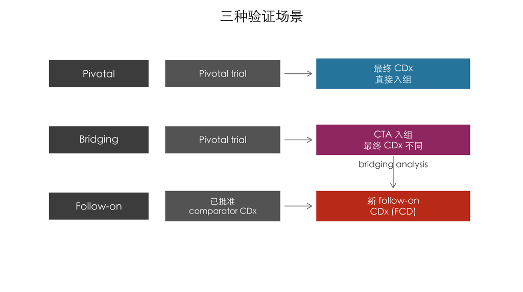

```r
par(family = "cjk", mar = c(1, 1, 3, 1))
plot(NA, xlim = c(0, 12), ylim = c(0, 7), axes = FALSE, xlab = "", ylab = "",
     main = "三种验证场景", cex.main = 1.6)
draw_box(1.8, 6, "Pivotal", "gray30", w = 2.6, h = 0.85, cex = 1.15)
draw_box(5.0, 6, "Pivotal trial", "gray40", w = 3.0, h = 0.85, cex = 1.05)
draw_box(9.4, 6, "最终 CDx\n直接入组", "#2E86AB", w = 4.0, h = 0.95, cex = 1.05)
draw_arr(6.6, 6, 7.3, 6)
draw_box(1.8, 4, "Bridging", "gray30", w = 2.6, h = 0.85, cex = 1.15)
draw_box(5.0, 4, "Pivotal trial", "gray40", w = 3.0, h = 0.85, cex = 1.05)
draw_box(9.4, 4, "CTA 入组\n最终 CDx 不同", "#A23B72", w = 4.0, h = 0.95, cex = 1.05)
draw_arr(6.6, 4, 7.3, 4)
draw_arr(9.4, 3.5, 9.4, 2.55, "bridging analysis", cex = 1.0)
draw_box(1.8, 2, "Follow-on", "gray30", w = 2.6, h = 0.85, cex = 1.15)
draw_box(5.0, 2, "已批准\ncomparator CDx", "gray40", w = 3.0, h = 0.95, cex = 0.95)
draw_box(9.4, 2, "新 follow-on\nCDx (FCD)", "#C73E1D", w = 4.0, h = 0.95, cex = 1.05)
draw_arr(6.6, 2, 7.3, 2)
```

- **Pivotal**（最理想，co-development）：药物 pivotal trial 入组时就用最终要上市的 CDx，上市 CDx 就是入组 assay。疗效证据直接属于 CDx+ 人群，统计上最干净，通常不需要 bridging。FDA 的总体原则也是尽可能同步开发并同期批准/许可治疗产品与其 CDx (U.S. Food and Drug Administration 2014, 2016)。
- **Bridging**（做不到同步时）：trial 开始时最终 CDx 还没定型，只能用 central lab assay、LDT（laboratory-developed test，实验室自建检测）、prototype、旧 cut-off、旧 platform 入组（即 CTA）。申报时最终 CDx 与 CTA 不一致，需 bridging analysis 把原 trial 疗效证据接到 CDx 定义的人群上 (U.S. Food and Drug Administration 2016; Song et al. 2024)。
- **Follow-on**（药物/CDx 已上市后）：另一个新检测（FCD）想拿同一适应症，不重新证明 biomarker-drug biology，而是证明自己与已批准的 comparator CDx（CCD）足够一致，间接支持 FCD+ 人群疗效 (Li 2016)。

一句话：bridging 解决”试验 assay 与最终 CDx 不一致”；follow-on 解决”新 CDx 能否替代已批准 CDx”。真实临床使用还更复杂——院内 NGS panel、LDT、商业综合 panel、不同样本类型，监管批准/报销/临床实际检测不总完全重合。两者各自的定义与做法，都放在后面「从生成模型到 follow-on 与 bridging」一章里展开（同一地基、两种搬运）。

# 2 试验设计：入组、对照、设盲

前面（§1.3）按”CDx 与入组 assay 的关系”分了三条路径。这一章换到设计层面：一个 CDx 试验具体怎么搭？

先给两组定义。伴随诊断 (companion diagnostic, CDx) 是为对应治疗产品安全有效使用提供必要信息的体外诊断设备 (U.S. Food and Drug Administration 2014)。围绕它：

- 两类主张：*Predictive*（预测性）——预测治疗对结局的差异效应，需 treatment × CDx 交互证据（marker+ 和 marker− 的疗效不同）；*Selection*（选择性）——只筛出用药亚群（通常 biomarker+），在选中人群证明有意义的疗效即可，不必量化 marker− 那侧。
- 两类验证：*Analytical*（分析验证）——精密度、准确度、干扰/稳健性；*Clinical*（临床验证）——识别/选择患者、预测差异获益的能力。

主张类型决定要拿什么证据；但落到怎么搭试验，有三个彼此独立的取舍，外加一条贯穿的纪律。这几件事最容易混，先用一张表钉清楚：

三个取舍 + 一条纪律

| 常听到的概念 | 其实属于 |
| --- | --- |
| 谁入组（富集只 CDx+ / 全员含 CDx−） | 取舍一 · 入组 |
| 随机化、要不要并行对照臂 | 取舍二 · 对照 |
| open-label、双盲/三盲、独立评估 BICR | 取舍三 · 设盲 |
| 揭盲前锁定 CDx 分析计划、防事后 post-hoc | 纪律 · 分析预设 |

- 取舍一 · 入组：谁进组？富集（只 CDx+，删 CDx−） vs 全员（含 CDx−）。
- 取舍二 · 对照：治疗组配不配并行对照？**随机对照试验（randomized controlled trial, RCT）** vs 单臂。
- 取舍三 · 设盲：瞒不瞒处理信息？双盲/三盲 vs open-label（外加独立评估 BICR）。
- 纪律 · 分析预设：CDx 的 assay/cutoff/分析计划必须在揭盲看数据前锁定，不做事后 post-hoc（这不是可选项，是纪律）。

三个取舍相互独立（一条怎么定，不限制另外两条）：富集人群里既能 RCT 也能单臂；RCT 既能双盲也能 open-label；单臂则必然 open-label（但仍保留 BICR）。下面逐条讲。

## 2.1 取舍一 · 入组谁：富集（删 CDx−）还是全员

理论上，predictive 主张要 marker-by-treatment 设计：CDx 检测后，CDx+ 与 CDx− 两个分层里都要做 1:1 随机化（治疗 vs 对照），这样才能估交互。可真做的时候（尤其肿瘤靶向药），CDx− 分层通常被整条筛除，既不入组也不随机（下图红叉）：

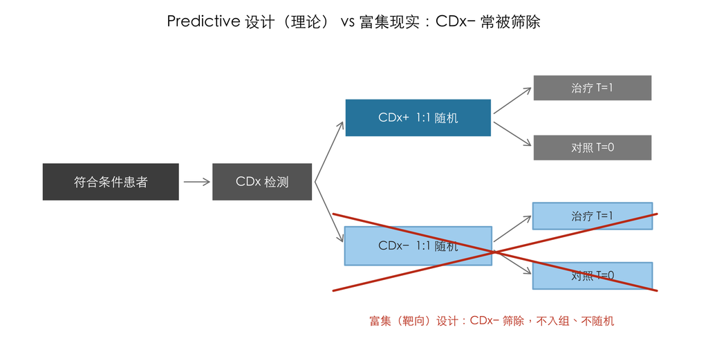

```r
par(family = "cjk", mar = c(0.5, 0.5, 3, 0.5))
plot(NA, xlim = c(0, 14), ylim = c(-0.6, 6), axes = FALSE, xlab = "", ylab = "",
     main = "Predictive 设计（理论） vs 富集现实：CDx− 常被筛除", cex.main = 1.3)
draw_box(1.7, 3, "符合条件患者", "gray30", w = 3.0, h = 0.9, cex = 1.05)
draw_box(5.0, 3, "CDx 检测", "gray40", w = 2.2, h = 0.9, cex = 1.05); draw_arr(3.3, 3, 3.85, 3)
# CDx+ 支路：实际入组、随机
draw_box(8.4, 4.5, "CDx+  1:1 随机", "#2E86AB", w = 3.2, h = 0.9, cex = 1.0)
draw_arr(6.15, 3, 6.75, 4.4)
for (yy in c(5.2, 3.8)) draw_box(12.2, yy, if (yy > 4.5) "治疗 T=1" else "对照 T=0", "gray55", w = 2.6, h = 0.62, cex = 0.95)
draw_arr(10.05, 4.6, 10.85, 5.2); draw_arr(10.05, 4.4, 10.85, 3.85)
# CDx- 支路：富集设计里筛除 —— 淡蓝（未入组）+ 划红叉
draw_box(8.4, 1.5, "CDx−  1:1 随机", "#AED6F1", w = 3.2, h = 0.9, cex = 1.0, txt = "gray20", border = "#7FB3D5")
draw_arr(6.15, 3, 6.75, 1.6)
for (yy in c(2.2, 0.8)) draw_box(12.2, yy, if (yy > 1.5) "治疗 T=1" else "对照 T=0", "#AED6F1", w = 2.6, h = 0.62, cex = 0.95, txt = "gray20", border = "#7FB3D5")
draw_arr(10.05, 1.6, 10.85, 2.2); draw_arr(10.05, 1.4, 10.85, 0.85)
segments(6.55, 2.25, 13.6, 0.45, col = "#C73E1D", lwd = 3)
segments(6.55, 0.45, 13.6, 2.25, col = "#C73E1D", lwd = 3)
text(10.0, -0.25, "富集（靶向）设计：CDx− 筛除，不入组、不随机", col = "#C73E1D", font = 2, cex = 0.95)
```

CDx− 被筛除有两条硬理由：

- 伦理：给预期无效的 marker− 患者上靶向药、或把他们放进对照臂承担风险与延误，站不住脚。
- 效率：marker− 会稀释总体疗效、抬高所需样本量。

于是绝大多数 CDx 试验退化成**富集（靶向）设计**：只入组阳性患者（实际是 CTA+），只在阳性人群里随机治疗 vs 对照。拿到的是 **selection 主张**（“阳性人群有效”），不是完整的 predictive/交互主张——图中下半条支路的数据从来没产生过。

这正是全文所有麻烦的根源。 因为 CDx−（以及后面会遇到的 CTA−/CDx+ 那一格）根本没被随机化、没有疗效数据，想把疗效证据搬到另一个 assay 定义的人群上，就只能对这些没观测到的格子做假设——这就是后面讲 bridging 时 $\delta_{01}$ 不可识别的由来。

那到底什么时候能删 CDx−、什么时候不能？ 取决于你要哪类主张：

- 能删（富集就够）：目标是 *selection* 主张（“该给谁用”），且有强生物学理由 + 既往证据表明 marker− 基本不获益——典型是药物直接靶向该突变产物：marker− 连靶点都没有，不可能获益，让他们上药纯担风险、进对照臂还延误治疗，伦理上也不该随机化。例：伊马替尼（BCR-ABL 融合，CML）、曲妥珠单抗（HER2 扩增，乳腺癌）、维莫非尼（BRAF V600E，黑色素瘤）、拉罗替尼/恩曲替尼（NTRK 融合，tumor-agnostic）——都只入组阳性、直接删 marker−。代价：只拿到阳性人群疗效，并留下缺失格子。
- 不能删（要全员/两层）：目标是 *predictive* 主张、必须证明疗效随 marker 不同（treatment × marker 交互）；或 marker− 是否获益本身存疑、cutoff 还没定、biomarker 的预测价值正是待验证的问题。这些情况下删掉 marker− 等于假设了本该由数据回答的东西。例：抗 EGFR 单抗（西妥昔单抗、帕尼单抗）治结直肠癌——正因为入组了全部患者，才发现 *KRAS* 突变者不但不获益、甚至更差，只有野生型获益；若一开始就富集野生型，根本无从证明突变型不该用。又如连续型 marker（如 PD-L1 TPS）cutoff 尚未确定时，得靠全员数据才能把阈值定在哪。

还有第三条折中路：全员入组、把 CDx 留到分析阶段才劈（prospective–retrospective 设计）。 全员随机化时不看 CDx，但每人都测，等分析计划锁定后再按 CDx 分层分析。合法与否只看一点——“预设”：assay、cutoff、分析计划必须在看到 biomarker 与结局的关系之前就冻结；反面是事后 post-hoc（跑完看了数据才挑 cutoff、挑分法），等于 data dredging，监管不认。例：上面 *KRAS* 的故事正是这么落地的——Karapetis、Amado 等（2008）用的是已完成的全员 RCT，*KRAS* 状态从存档肿瘤样本回测，但 treatment × KRAS 的分析是预先设定的；所以尽管是”回溯”分析，监管仍然采信，并据此把抗 EGFR 单抗的适应症限定到 *KRAS* 野生型。

这里的”锁定/冻结”指分析层面的预设（对应上表的”纪律 · 分析预设”）——在主分析揭盲、看 biomarker–结局关系之前把 CDx 分析定死，防挑数据；它不是对医生/患者设盲，设盲是取舍三的事，具体到（§2.3）再展开。

## 2.2 取舍二 · 对照怎么设：RCT 还是单臂（删对照）

取舍一确定的是”入组谁”；这一节是另一个独立的问题：入组之后，治疗组要不要配一个并行对照臂？这跟删不删 CDx− 完全是两回事——富集人群里照样可以做 RCT，也可以删掉对照臂做**单臂试验（single-arm trial, SAT）**（见下方单臂示意图）。精准医疗里相当一部分获批走的正是单臂。下面把这条取舍讲清：为什么能单臂、什么时候必须 RCT。

RCT：金标准，但在精准医疗里有门槛。 RCT 能估比较性获益——即”用了这个药，比不用（或用现有标准治疗）好多少”。因为治疗组和对照组来自同一批随机分配的患者、预后分布一致，两组的差异才能干净地归因于药物，而不是病情本身或人群差异。度量上通常用 PFS（progression-free survival，无进展生存期）或 OS（overall survival，总生存期）的**风险比 (hazard ratio, HR)**：HR<1 表示试验药相对对照把”进展/死亡”的瞬时风险降低了多少（如 HR=0.6 ≈ 风险降 40%）。这种”相对某个对照”的比较性证据，是完全批准（full approval）和比较性主张的金标准——单臂试验给不出，因为它没有并行对照。

*PFS/OS 具体怎么算（两臂各算一套）。* 它们都是事件时间终点，从随机化那天（t=0）起算，逐患者记一个 (时间, 是否事件) 对：**OS** = 到任何原因死亡的时间；**PFS** = 到疾病进展（影像按 RECIST 判定肿瘤增大/新病灶）或死亡、谁先算谁。到数据截止还活着 / 无进展 / 失访的患者不是没结果，而是删失 (censored)——只知道”至少活/无进展到这天”，之后未知。每个臂把本臂所有患者的这些 (时间, 事件/删失) 汇总成一条 Kaplan–Meier 生存曲线（曲线每遇一个事件下一个台阶，删失只做标记不下台阶），曲线降到 0.5 处即中位 PFS/OS。两臂比较：log-rank 检验看曲线整体是否不同，Cox 模型给出 HR（两臂瞬时事件风险之比）。所以实验组、对照组各有自己的 PFS 曲线和 OS 曲线，“疗效”就是两条曲线之间的差（HR 或中位差）。

RCT 的好处（为什么是金标准）：

- 可比性：随机化让两臂预后分布一致，组间差异能干净归因于药，而非人群或病情差异。
- 比较性主张：直接回答”比现有治疗好多少”，支撑完全批准与优效/非劣标签。
- 硬终点的相对量：OS/PFS 的 HR 有并行对照做参照，不必依赖历史/自然史假设。
- 可设盲：有对照才盲得起来，压住主观评估与安慰剂效应偏倚（见取舍三）。

RCT 的坏处（代价与陷阱——多数不是精准医疗独有，是所有 RCT 的通病）：

- 样本与成本：要两臂各自够人数；marker+ 罕见时凑不齐（这条精准医疗尤其突出）。
- 伦理：疗效巨大又无有效替代时，把人随机到对照臂难以接受。
- crossover 稀释 OS（任何允许交叉的 RCT 共有，下图）：对照组进展后换用试验药会抬高对照组生存、抹平两臂 OS 差距。
- OS 受后线治疗混杂（任何随访够长的 RCT 都有）：OS 到死亡为止，中间夹多线其他药，难把生存差异归因给最初这一个。
- assay 依赖（精准医疗特有）：CDx 必须入组时就能用，否则落回 bridging。

crossover 为什么稀释 OS。 这不是精准医疗的特殊问题，是所有允许交叉的 RCT 的结构性代价。OS 只算到死亡：对照组病人进展后换到有效试验药，虽然晚了几个月，最终也吃上了药、也活长了 → 两臂 OS 拉不开。PFS 只算到第一次进展，而进展正是触发换药的事件、发生在换药之前 → PFS 不被污染。所以有 crossover 风险时，主要终点常从 OS 退到 PFS。下图用模拟 Kaplan–Meier 曲线对比——同一个实验组，只改对照组是否 crossover：

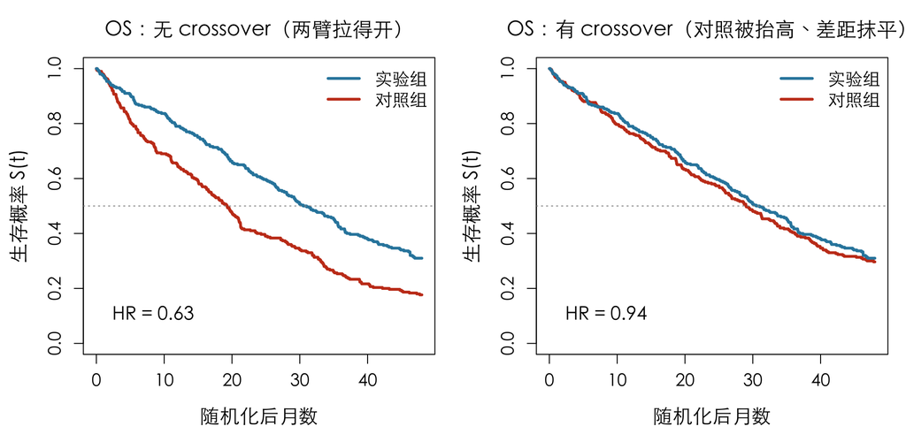

```r
suppressMessages(library(survival))
set.seed(7)
par(family = "cjk", mfrow = c(1, 2), mar = c(4.4, 4.6, 3.2, 1))
ln2 <- log(2); cens <- 48; n <- 300
rmed <- function(n, m) rexp(n, ln2 / m)
mk <- function(t) data.frame(t = pmin(t, cens), ev = as.integer(t <= cens))
t_trt <- rmed(n, 30)     # 实验组 OS 中位 ~30
t_c0  <- rmed(n, 18)     # 对照 无 crossover 中位 ~18
t_c1  <- rmed(n, 27)     # 对照 有 crossover: 换药后 OS 被抬到 ~27, 逼近实验组
kmplot <- function(dt, dc, main) {
  d <- rbind(cbind(dt, arm = "trt"), cbind(dc, arm = "ctrl"))
  f <- survfit(Surv(t, ev) ~ arm, data = d)
  hr <- summary(coxph(Surv(t, ev) ~ (arm == "trt"), data = d))$coef[2]  # exp(coef)=HR 实验 vs 对照
  plot(f, col = c("#C73E1D", "#2E86AB"), lwd = 3, xlim = c(0, cens),
       xlab = "随机化后月数", ylab = "生存概率 S(t)", cex.lab = 1.3, cex.axis = 1.15, mark.time = FALSE)
  title(main = main, cex.main = 1.35)
  legend("topright", c("实验组", "对照组"), col = c("#2E86AB", "#C73E1D"), lwd = 3, bty = "n", cex = 1.15)
  abline(h = 0.5, lty = 3, col = "gray60")
  text(1, 0.10, sprintf("HR = %.2f", hr), pos = 4, cex = 1.25, font = 2)
}
kmplot(mk(t_trt), mk(t_c0), "OS：无 crossover（两臂拉得开）")
kmplot(mk(t_trt), mk(t_c1), "OS：有 crossover（对照被抬高、差距抹平）")
```

左图无 crossover，两臂拉得开、HR≈0.63 显示获益；右图对照组进展后换药，OS 曲线被抬到几乎与实验组重合、HR≈0.94，“看着没效”——但药其实一样有效，只是 OS 这把尺子被 crossover 稀释了。PFS（算到进展、在换药之前）在两种情形下都能保住获益，这就是它常被选作主要终点的原因。

RCT 更适合人群较大、有真实对照药的场景——例：曲妥珠单抗（HER2+ 乳腺癌）、维莫非尼（BRAF V600E 黑色素瘤，BRIM-3 拿到 OS 获益）、克唑替尼确证性 RCT（PROFILE 1007/1014）。

单臂试验（SAT）：为什么可以，什么时候用。 单臂没有对照，人人服药，主要终点是客观缓解率（ORR）+ 缓解持续时间（DoR），与预设的历史/自然史阈值比。它站得住脚的核心统计理由是：肿瘤缩小是可归因于药的事件——肿瘤不会自己缩，所以”客观缓解”这种终点不像 PFS/OS 那样严重依赖预后和自然史，不必靠并行随机对照来归因。适用条件：marker 罕见（如 NTRK 融合 <1%，无法凑够随机样本）、预期疗效巨大、未满足的临床需求大、走加速批准（accelerated approval）。例：拉罗替尼/恩曲替尼（NTRK 融合，tumor-agnostic 篮子试验，按 ORR 获批）、帕博利珠单抗（MSI-H/dMMR，跨瘤种单臂）、奥希替尼（EGFR T790M，AURA 单臂加速批准）、克唑替尼最初的单臂加速批准（PROFILE 1001）。

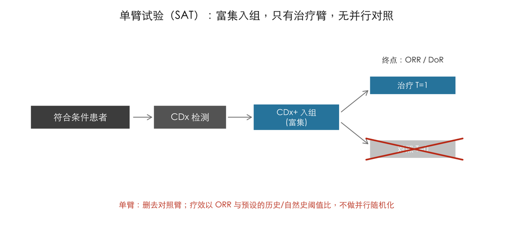

```r
par(family = "cjk", mar = c(0.5, 0.5, 3, 0.5))
plot(NA, xlim = c(0, 14), ylim = c(-0.6, 6), axes = FALSE, xlab = "", ylab = "",
     main = "单臂试验（SAT）：富集入组，只有治疗臂，无并行对照", cex.main = 1.3)
draw_box(1.7, 3, "符合条件患者", "gray30", w = 3.0, h = 0.9, cex = 1.05)
draw_box(5.0, 3, "CDx 检测", "gray40", w = 2.2, h = 0.9, cex = 1.05); draw_arr(3.3, 3, 3.85, 3)
draw_box(8.2, 3, "CDx+ 入组\n(富集)", "#2E86AB", w = 2.6, h = 1.0, cex = 0.95); draw_arr(6.15, 3, 6.85, 3)
# 只有治疗臂
draw_box(11.7, 4.2, "治疗 T=1", "#2E86AB", w = 2.6, h = 0.7, cex = 0.95); draw_arr(9.55, 3.2, 10.35, 4.0)
text(11.7, 5.15, "终点：ORR / DoR", cex = 0.9, col = "gray20", font = 3)
# 对照臂被删 —— 灰掉 + 红叉
draw_box(11.7, 1.8, "对照 T=0", "gray80", w = 2.6, h = 0.7, cex = 0.95); draw_arr(9.55, 2.8, 10.35, 2.0)
segments(10.3, 2.2, 13.2, 1.4, col = "#C73E1D", lwd = 3)
segments(10.3, 1.4, 13.2, 2.2, col = "#C73E1D", lwd = 3)
text(7.0, -0.3, "单臂：删去对照臂；疗效以 ORR 与预设的历史/自然史阈值比，不做并行随机化",
     col = "#C73E1D", font = 2, cex = 0.92)
```

怎么选。 现实里常见的是先后接力：先单臂拿加速批准、再补确证性 RCT（克唑替尼、奥希替尼都走这条）。一句话决策规则：marker 越罕见、效应越戏剧化、越无替代药 → 越倾向单臂；人群越大、越需要比较 PFS/OS、越有现成对照 → 越必须 RCT。

各自要盯的问题。

- RCT 要注意：marker− 通常被筛除（见上图），拿到的是 selection 而非完整 predictive；对照组 crossover 会稀释 OS；OS 受后线治疗混杂，常用 PFS 替代；assay 要提前锁定并在入组时可用；多个 biomarker 亚组带来多重性问题。
- 单臂要注意：没有对照，只能证明药物活性（ORR），不能直接估比较性获益；历史对照有偏（患者选择、标准治疗随时间变好、支持治疗进步都会抬高表观疗效）；ORR 作为替代终点的可信度要够，通常还需确证性试验；无法把预后因素和预测因素分开；盲态只能靠 BICR（见取舍三）。

## 2.3 取舍三 · 要不要设盲：open-label、双/三盲与 BICR

金标准 RCT 讲三盲：①病人盲（不知自己在治疗组还是对照组）、②医生/研究者盲、③独立评估与数据分析盲（影像/病理由独立评审判读、统计分析也盲态）。要害是：设盲得靠对照才盲得起来——你得有”治疗 vs 安慰剂/对照”这层可瞒；没有对照，前两盲根本无从谈起。所以设盲和取舍二（对照）相关，但不是同一件事：

- 有对照的 RCT：可做双盲/三盲（安慰剂对照）；也可以是 open-label RCT——仍随机、仍有对照，但因伦理或操作（如手术 vs 药）瞒不住，病人/医生开放。
- 单臂：人人吃药，必然 open-label——①②两盲天生做不到；但第③盲保得住：缓解由**盲态独立中心评审（BICR，blinded independent central review）**判读，挡住开放标签下的评估偏倚。

三盲各防一种偏倚，单臂能保住哪层一目了然：

三盲各防一种偏倚，单臂能保住哪层

| 盲谁 | 防的偏倚 | 单臂能否做到 |
| --- | --- | --- |
| ① 病人 | 安慰剂效应、依从/退出差异 | ✗（人人吃药） |
| ② 医生/研究者 | 用药、剂量调整、主观评估倾向 | ✗ |
| ③ 独立评估 + 分析（BICR / 统计） | 评估者、分析者偏倚 | ✓（靠 BICR） |

别和”分析预设”混。 取舍一提过的”揭盲前锁定 CDx 分析计划”，那个”揭盲”指试验末数据库/治疗码揭盲的时间点，要求 biomarker 分析在此之前冻结——是分析纪律（防 post-hoc 挑数据），和”病人/医生知不知道谁在治疗组”无关。一句话：设盲管”知不知道处理”，分析预设管”看数据的先后顺序”，两回事。

回到本文框架。 worked example 里的疗效是随机臂之差 $\delta = \mathrm{E}[Y\mid T{=}1] - \mathrm{E}[Y\mid T{=}0]$；换成单臂时，被搬运的量就从”治疗效应差”变成”assay+ 人群的应答率”。但底层逻辑完全一样：不完美 assay 让阳性人群混进真阴性，应答率（或疗效）被 PPV 稀释，换一个 assay 就得 bridging 把它搬到新人群上。所以后文所有公式对 RCT 和单臂都成立——区别只在”疗效”这个词具体指风险比（HR）还是应答率（ORR）。

# 3 地基（DGP）：先造一个已知真相的世界

这一章是地基（DGP，Data Generating Process，数据生成过程）——后面 bridging、follow-on 两章都站在它上面。地基其实有两层，要一起搭：

- 概念地基——一套贯穿全文的记号，和一条主恒等式。记号只有三家：真值 $\mu$（按真实 marker 分）、FCD+ 人群疗效 $\eta$、CCD+ 人群疗效 $\theta$。主恒等式一句话——任何 assay 判为阳性的那群人，其疗效都是”两块真疗效积木”按该 assay 的 PPV 混出来的。把这一句吃透，后面 bridging、follow-on 全是它的特例。
- 模拟地基——一个自己偷偷知道全部真相的世界，让上面那些抽象记号落成能对撞验证的真实数字：$\eta$、$\theta$ 到底是多少、混合公式对不对，都能在这个世界里数出来核对。

两层穿插着搭（这正是本章比”光有公式”或”光有数据”更值的地方）：每立一个概念，随即用模拟把它兑现成数字、当场验证。动手之前，先把整条方法线要解决的问题摆出来。

两个具体问题（都是同一件事的两种形态：疗效证据能不能跨 assay 搬运）：

1. follow-on：一个新检测 FCD 想拿到和已批准 CCD 一样的适应症。问——FCD 和 CCD 判人到底有多一致？能不能借 CCD 已确立的疗效证据、反推”FCD 判阳的人群”疗效可接受，而不必重做一遍临床试验？
2. bridging：试验当年用 CTA 入组，最终上市换成了 CDx。问——原试验在 CTA+ 人群拿到的疗效，还算不算 CDx+ 人群的？难点在于富集试验只留下了 CTA+ 的人，CTA−/CDx+ 那一格根本没有病人，这块疗效怎么补？

为什么先搭一个模拟器，而不是直接上真实数据？ 因为这两个问题的要命之处是真相不可观测：真实 marker 状态 $G$ 看不到、CTA−/CDx+ 那格没有病人、缺失格子的疗效 $\delta_{01}$ 无从测量。在真实数据里，你永远没法验证一个 bridging 估计到底对不对——手里没有标准答案可对。所以本章的办法是：先造一个自己偷偷知道全部真相的世界（下面的”生成模型” DGP），在里面按各种真实设计抽样、跑公式，再把结果和那个只有”上帝视角”才知道的真值对撞。公式能还原真相，才敢把它用到真实数据上；还原不了的地方，恰好暴露出”哪一步只能靠假设、不能靠数据”。

顺序：先搭地基——最小符号、“已知真相的世界”、自洽验证，并把”不完美 assay 会稀释疗效”这个两种搬运都要用的通用事实立起来（结局层）→ 再讲 bridging（本文主角：自己试验有疗效，要把它从 CTA+ 人群搬到 CDx+，难在缺失格子）→ 最后讲 follow-on（换一种缺失结构：自己不做疗效试验，靠与已批准 CCD 的一致性间接搬运）。bridging 和 follow-on 是同一类问题、只是缺失结构不同（详见末章「综述」对照表）；同一个生成器在末章「进阶」继续复用。

## 3.1 最小符号与生成模型

worked example 的地基是一个已知真相的世界。先搭最小的两层，全部围绕潜在真实 marker 状态 $G$：

- 真相层：$G$ 是每个人潜在的真实 marker 状态，二值——$G{=}1$ 真阳性、$G{=}0$ 真阴性。只需一个参数 $\Pr(G{=}1)=\text{prev}_G$（真实患病率），$\Pr(G{=}0)=1-\text{prev}_G$ 随之确定。
- assay 层：每个检测（CTA、最终 CDx、comparator CCD、pre-screen）是 $G$ 的噪声分类器，各有敏感度 $\Pr(\text{assay}{=}1\mid G{=}1)$ 和特异度 $\Pr(\text{assay}{=}0\mid G{=}0)$；给定 $G$ 条件独立（CCD 两次重复也独立）。

第三层”结局层”（连续端点 $Y$、疗效 $\delta$）先不加——讲到疗效混合时再补（见 §「加结局层：疗效混合」）。好处：一切一致性和混合效应都由共同原因 $G$ 自动自洽诱导，不用手拼一堆可能矛盾的边际概率。

上面两层、以及由它们直接导出的基础符号，严格写出来如下（`Pr(·)` 是概率，竖线 `|` 读作”在……已知的条件下”）：

本文基础符号（真相层 + assay 层）：严格定义

| 符号 | 严格定义 | 层 / 说明 |
| --- | --- | --- |
| G | 真实 marker 状态：G=1 真阳、G=0 真阴 | 真相层 · 潜在不可观测，需参考标准才知道 |
| prevG（π） | Pr(G=1)，真实患病率（1−π = Pr(G=0)） | 真相层 · 唯一的患病率参数 |
| T | 治疗臂：T=1 治疗、T=0 对照 | 结局层 · §「结局层」引入结局 Y 时才用到 |
| assay A | 任一检测（G 的噪声分类器）；本文 A ∈ {CTA, FCD（=最终 CDx）, CCD, Pre} | assay 层 · A 是占位符，代入具体检测即得该检测的量 |
| sensA / specA | 敏感度 sensA = Pr(A=1\|G=1)； 特异度 specA = Pr(A=0\|G=0) | assay 层 · 在 TRUTH 里直接给定（生成参数） |
| PPVA / NPVA | 阳性预测值 PPVA = Pr(G=1\|A=1)； 阴性预测值 NPVA = Pr(G=0\|A=0) | assay 层 · 由 sens/spec 与患病率 π 经 Bayes 导出，非自由参数 |

这一层的量都是”标签或概率”（下一节结局层才出现可正可负的疗效实数）：$G$、$T$ 是二值标签 $\{0,1\}$；$\pi$、$sens/spec$、$PPV/NPV$ 都是 $0$–$1$ 的概率。本文 DGP 的具体取值——$\pi=0.30$；四个检测 $sens/spec$ 依次 CTA 0.85 / 0.90、CDx(=FCD) 0.95 / 0.96、CCD 0.93 / 0.94、Pre 0.80 / 0.75；由此贝叶斯算出 $PPV_f\approx0.91$、$PPV_c\approx0.87$。

为什么 $\pi=0.30$？ 它本质只是 DGP 的一个固定已知参数，取任何值都能验证公式；选 0.30 图两点：一是真实——很多肿瘤 biomarker 的患病率就落在 20–40%；二是教学清晰——特意避开 0.5（太对称，掩盖患病率对 PPV 的影响）和极端值（罕见 marker 会让 PPV 崩到很低、例子失真），这样”不完美 assay 稀释疗效”的效应既清楚可见、又不夸张（$\pi=0.30$ 下 CDx 这么好的检测 $PPV_f$ 也才 $0.91$、不到 1，稀释一眼看得见）。四个检测的 $sens/spec$ 同理特意拉开档次（CDx 最好、Pre 最差），好让”assay 越好、$PPV$ 越高、稀释越少”的对比一目了然。

下标就是”哪一个检测”，不用猜：$A$ 只是占位符，代入具体检测就得到那个检测的量——本文固定 $f$ = FCD（最终 / 新 CDx，是 FCD 的缩写，不是字母”f”某检测）、$c$ = CCD（comparator CDx）。于是 $PPV_f=\Pr(G{=}1\mid FCD{=}1)$、$PPV_c=\Pr(G{=}1\mid CCD{=}1)$，$sens_A$、$spec_A$ 同理。

而且 $PPV$ 不是可以随手假设的旋钮。 它由贝叶斯从三样东西钉死：该检测的 $sens$、$spec$，加上这个 marker 的真实患病率 $\pi$： $PPV=\dfrac{sens\cdot\pi}{sens\cdot\pi+(1-spec)(1-\pi)}$。要害在 $\pi$：不同 marker 在人群里的分布差别极大，罕见 marker（$\pi$ 小）即便检测很准，$PPV$ 也可能很低（阳性里混进大量假阳）。所以 $PPV$ 是 marker 特异的、可行范围有限——一旦锁定某个具体 marker 的 assay，它的 $PPV$ 基本被 $(sens,spec,\pi)$ 定死，不能拍脑袋给。（这条贝叶斯关系，§「贝叶斯」那节还会用模拟验证。）

结局层的 $Y$、$\mu$、$\delta_{\text{pos}}/\delta_{\text{neg}}$、$\eta$、$\theta$ 到 §「加结局层」再严格定义（见那里的”三级台阶”表）；派生的一致性量 **PPA/NPA**、搬运权重 $p$ 在 §「生成器、真值算子与自洽验证」一节就地给出；全部符号另见文末〈记号表〉。

```r
TRUTH <- list(
  prev_G = 0.30,                                     # Pr(G=1)
  assays = list(
    CTA = c(sens = 0.85, spec = 0.90),               # clinical trial assay (入组用)
    CDx = c(sens = 0.95, spec = 0.96),               # 最终 CDx / FCD (最好)
    CCD = c(sens = 0.93, spec = 0.94),               # comparator CDx (follow-on 参照)
    Pre = c(sens = 0.80, spec = 0.75)                # pre-screen (粗筛, 最差)
  ),
  endpoint = list(mu_G1_T0 = 0, delta_pos = 0.60,    # 真 marker+: 对照均值0, 治疗 +0.60
                  mu_G0_T0 = 0, delta_neg = 0.05,    # 真 marker-: 药物几乎无效
                  sd = 1.0)
)
```

角色 → 数据列映射（角色定义见 §1.1，此处只说代码里落到哪列）：`CDx` 列 = FCD（新检测/最终 CDx）——注意别被列名误导，FCD 在代码里就是 `CDx`；`CCD1`/`CCD2` = CCD 的两次独立重复；`CTA` 列 = CTA；`Pre` 列 = 粗筛。

## 3.2 生成器、真值算子与自洽验证（先只验 assay 层）

两样东西配成一对——一个造数据、一个给标准答案：

- **`generate_population()`** — 模拟器：先按 prevalence 抽真状态 $G$，再让每个 assay 当 $G$ 的噪声分类器（sens/spec 决定翻转概率、给定 $G$ 独立）各自出结果。它也能顺带生成结局 $Y$（`with_endpoint=TRUE`），但那一层这一节先不用。给样本量 $n$，吐一个数据集。
- **闭式真值算子** — 不抽样，直接从 `TRUTH` 算理论真值，当”标准答案”。这一节先用三个纯 assay 层（不涉及疗效）的：
  - `assay_prev()`：某 assay 的边际阳性率 $\Pr(\text{assay}{=}1)$。
  - `true_concordance()`：两 assay 的真 PPA/NPA——泛化定义 **PPA** = $\Pr(B{+}\mid A{+})$（A 判阳的人里 B 也判阳的比例）、**NPA** = $\Pr(B{-}\mid A{-})$，在共同 $G$ 下用联合概率算，不靠样本。
  - `true_p_cta_given_cdx()`：$p=\Pr(CTA{+}\mid CDx{+})$，bridging 的关键权重。

第四个算子 `true_delta_in_assay_pos()` 属结局层，等加了疗效再定义。套路统一：模拟估计 → 和闭式真值对撞 → 验证公式。

```r
generate_population <- function(n, truth = TRUTH, with_endpoint = FALSE) {
  G <- rbinom(n, 1, truth$prev_G)
  call_assay <- function(oc) ifelse(G == 1, rbinom(n, 1, oc["sens"]), rbinom(n, 1, 1 - oc["spec"]))
  df <- data.frame(G = G, CTA = call_assay(truth$assays$CTA), CDx = call_assay(truth$assays$CDx),
                   CCD1 = call_assay(truth$assays$CCD), CCD2 = call_assay(truth$assays$CCD),
                   Pre = call_assay(truth$assays$Pre))
  if (with_endpoint) {                                   # 结局层：讲疗效时才用到
    ep <- truth$endpoint; T_arm <- rbinom(n, 1, 0.5)
    mu <- ifelse(G == 1, ep$mu_G1_T0 + T_arm*ep$delta_pos, ep$mu_G0_T0 + T_arm*ep$delta_neg)
    df$T_arm <- T_arm; df$Y <- rnorm(n, mu, ep$sd)
  }
  df
}

# assay 层算子：边际阳性率; 两 assay 真 PPA/NPA; true p=Pr(CTA+|CDx+)。(δ 算子在结局层再定义)
assay_prev <- function(oc, prev = TRUTH$prev_G) oc["sens"]*prev + (1-oc["spec"])*(1-prev)
true_concordance <- function(ocA, ocB, prev = TRUTH$prev_G) {
  pA1 <- function(g) if (g == 1) ocA["sens"] else 1-ocA["spec"]
  pB1 <- function(g) if (g == 1) ocB["sens"] else 1-ocB["spec"]
  jt <- function(a,b) sum(sapply(0:1, function(g){
    pa <- if(a==1) pA1(g) else 1-pA1(g); pb <- if(b==1) pB1(g) else 1-pB1(g)
    pa*pb*(if(g==1) prev else 1-prev)}))
  c(PPA = unname(jt(1,1)/(jt(1,1)+jt(1,0))), NPA = unname(jt(0,0)/(jt(0,0)+jt(0,1))))
}
true_p_cta_given_cdx <- function(truth = TRUTH) {
  oc_c <- truth$assays$CTA; oc_d <- truth$assays$CDx; prev <- truth$prev_G
  num <- sum(sapply(0:1, function(g){pc<-if(g==1)oc_c["sens"] else 1-oc_c["spec"]; pd<-if(g==1)oc_d["sens"] else 1-oc_d["spec"]; pc*pd*(if(g==1)prev else 1-prev)}))
  den <- sum(sapply(0:1, function(g){pd<-if(g==1)oc_d["sens"] else 1-oc_d["spec"]; pd*(if(g==1)prev else 1-prev)}))
  unname(num/den)
}
```

算子和生成器都齐了，当场”对表”验一次自洽——但先只验 assay 层（一致性 + $p$，还不碰疗效）：同一批真值用两条独立路子各算一遍——闭式（直接拿参数套公式）vs 模拟 200 万人再数比例（经验值）。两列几乎相等（“差”列≈0）就说明公式和模拟器都没写错、DGP 自洽——之后各节才敢直接拿闭式真值当基准。

```r
big <- generate_population(2e6)
tc  <- true_concordance(TRUTH$assays$CTA, TRUTH$assays$CDx)   # 命名向量 c(PPA=, NPA=)
closed <- c(tc[["PPA"]], tc[["NPA"]], true_p_cta_given_cdx())  # [[ ]] 取值、不带元素名
emp <- c(mean(big$CDx[big$CTA==1]==1),                         # Pr(CDx+|CTA+) = PPA
         mean(big$CDx[big$CTA==0]==0),                         # Pr(CDx−|CTA−) = NPA
         mean(big$CTA[big$CDx==1]==1))                         # Pr(CTA+|CDx+) = p
ft_show(data.frame(
  `量` = c("PPA_{CTA,CDx} = Pr(CDx+|CTA+)",
           "NPA_{CTA,CDx} = Pr(CDx−|CTA−)",
           "p = Pr(CTA+|CDx+)"),
  `闭式真值` = round(closed, 4),
  `模拟 2M 估计` = round(emp, 4),
  `差` = round(abs(closed - emp), 4),
  check.names = FALSE),
  title = "概念真值表（assay 层）：闭式真值 vs 模拟估计")
```

概念真值表（assay 层）：闭式真值 vs 模拟估计

| 量 | 闭式真值 | 模拟 2M 估计 | 差 |
| --- | --- | --- | --- |
| PPACTA,CDx = Pr(CDx+\|CTA+) | 0.7540 | 0.7532 | 0.0008 |
| NPACTA,CDx = Pr(CDx−\|CTA−) | 0.8993 | 0.8994 | 0.0001 |
| p = Pr(CTA+\|CDx+) | 0.7829 | 0.7831 | 0.0002 |

✓ DGP（assay 层）自洽，可以拿它当后面各节的”标准答案”。

## 3.3 加”结局层”：疗效混合

问题：一个不完美的 assay 判为阳性的那群人，他们的表观疗效，比真 marker+ 人群的疗效低多少？ 这是 bridging 和 follow-on 都要用的通用事实——两种搬运搬的都是”assay 定义人群的疗效”，而它天生被 assay 的不完美稀释。所以放在地基里先讲清楚，回答它要用到疗效，正好把之前搁置的第三层补上。

到这里才需要疗效，把第三层补上。结局层：连续端点 $Y$，均值只取决于治疗臂 $T$ 和真实 $G$；真 marker+ 疗效 $\delta_{\text{pos}}$、真 marker− 疗效 $\delta_{\text{neg}}$ 各自给定——`generate_population(..., with_endpoint = TRUE)` 生成的正是这一层。同时补上属结局层的第四个算子：

```r
true_delta_in_assay_pos <- function(oc, truth = TRUTH) {   # assay+ 人群真疗效 = PPV 加权 δ
  prev <- truth$prev_G
  ppv <- oc["sens"]*prev / (oc["sens"]*prev + (1-oc["spec"])*(1-prev))
  unname(ppv*truth$endpoint$delta_pos + (1-ppv)*truth$endpoint$delta_neg)
}
```

它一上来就讲故事：真 marker+ 疗效 0.60，但 CDx+ 人群只 0.551（不完美 assay 把真阴性混进来、稀释），CTA+ 人群更低 0.482（CTA 更差）——bridging 要把 CTA+ 观测的疗效往 CDx+ 调，正是它存在的意义。

正式写出来前，先立只有两块的”积木”。把人按 (治疗臂 $T$, 真实 marker 状态 $G$) 分成四格，每格的结局均值记 $\mu_{TG}$：

四格结局均值 μ（行=治疗臂 T，列=真 marker G）

|  | 真 marker+ (G=1) | 真 marker− (G=0) |
| --- | --- | --- |
| 治疗 T=1 | μ11 | μ10 |
| 对照 T=0 | μ01 | μ00 |

这四格从哪来？一张图看清——先按真 marker $G$ 把人分两支（两支都留），每支再 1:1 随机成治疗 / 对照，就落成四格 $\mu_{TG}$：

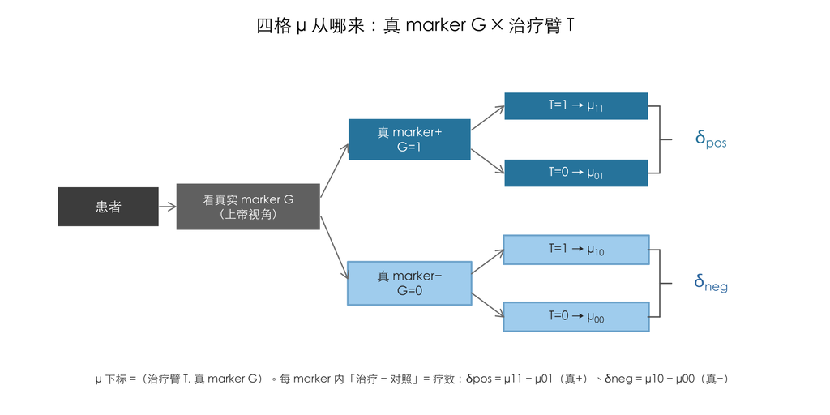

```r
par(family = "cjk", mar = c(0.5, 0.5, 3, 0.5))
plot(NA, xlim = c(0, 14), ylim = c(-0.9, 6), axes = FALSE, xlab = "", ylab = "",
     main = "四格 μ 从哪来：真 marker G × 治疗臂 T", cex.main = 1.3)
draw_box(1.3, 3, "患者", "gray30", w = 1.9, h = 0.85, cex = 0.95)
draw_box(3.9, 3, "看真实 marker G\n（上帝视角）", "gray45", w = 2.7, h = 1.0, cex = 0.85)
draw_arr(2.25, 3, 2.55, 3)
draw_box(6.9, 4.4, "真 marker+\nG=1", "#2E86AB", w = 2.3, h = 0.9, cex = 0.9)
draw_box(6.9, 1.4, "真 marker−\nG=0", "#AED6F1", w = 2.3, h = 0.9, cex = 0.9, txt = "gray20", border = "#7FB3D5")
draw_arr(5.25, 3.2, 5.75, 4.3); draw_arr(5.25, 2.8, 5.75, 1.5)
draw_box(10.0, 5.1, bquote(paste("T=1 → ", mu["11"])), "#2E86AB", w = 2.7, h = 0.6, cex = 0.9)
draw_box(10.0, 3.7, bquote(paste("T=0 → ", mu["01"])), "#2E86AB", w = 2.7, h = 0.6, cex = 0.9)
draw_box(10.0, 2.1, bquote(paste("T=1 → ", mu["10"])), "#AED6F1", w = 2.7, h = 0.6, cex = 0.9, txt = "gray20", border = "#7FB3D5")
draw_box(10.0, 0.7, bquote(paste("T=0 → ", mu["00"])), "#AED6F1", w = 2.7, h = 0.6, cex = 0.9, txt = "gray20", border = "#7FB3D5")
draw_arr(8.05, 4.6, 8.65, 5.1); draw_arr(8.05, 4.2, 8.65, 3.7)
draw_arr(8.05, 1.6, 8.65, 2.1); draw_arr(8.05, 1.2, 8.65, 0.7)
brace(11.55, 3.7, 5.1); text(12.5, 4.4, bquote(delta[pos]), col = "#2E86AB", cex = 1.25, font = 2)
brace(11.55, 0.7, 2.1); text(12.5, 1.4, bquote(delta[neg]), col = "#3B7DB0", cex = 1.25, font = 2)
text(7, -0.6, "μ 下标 =（治疗臂 T, 真 marker G）。每 marker 内「治疗 − 对照」= 疗效：δpos = μ11 − μ01（真+）、δneg = μ10 − μ00（真−）",
     col = "gray25", cex = 0.8, font = 3)
```

μ 的两位下标就是这么来的：第一位 = 治疗臂 $T$（哪一支：治疗 / 对照）、第二位 = 真 marker $G$（哪一列：真+ / 真−）。每一列的”治疗 − 对照”就是那个真实人群的治疗效应——全文只有这两块积木：

$$\delta_{\text{pos}}=\mu_{11}-\mu_{01}\
(\text{真 marker+ 的疗效}),\qquad \delta_{\text{neg}}=\mu_{10}-\mu_{00}\
(\text{真 marker− 的疗效}).$$

这些 $\mu$ 是什么数？ 把 $Y$ 想成一个连续疗效读数（比如肿瘤缩小量、某评分的变化，单位随意），$\mu_{TG}$ 就是某一格人 $Y$ 的平均值——一个实数，可正可负，不是百分比。本文把对照臂均值设成基准 0，代入 DGP 的参数就是：$\mu_{01}=0$（marker+ 对照）、$\mu_{11}=0.60$（marker+ 用药，平均比对照高 0.60）、$\mu_{00}=0$（marker− 对照）、$\mu_{10}=0.05$（marker− 用药，几乎没动）。相减即疗效：$\delta_{\text{pos}}=0.60-0=0.60$、$\delta_{\text{neg}}=0.05-0=0.05$。个体的 $Y$ 再在这均值上下按正态分布（均值 $\mu$、标准差 $1$）抖动，所以某个 marker+ 用药者可能 $Y=1.3$、也可能 $Y=-0.2$。记住两类量别混：$\mu$、$\delta$、$\eta$、$\theta$ 是疗效读数或其差，实数、可正可负；而 $\pi$、$sens/spec$、$PPV$、$PPA$、$p$、$c$ 是概率或比率，取值都在 $0$ 与 $1$ 之间。

有真 $G$ 时，FCD+ 人群的表观疗效 $\eta$ 就是这两块积木的加权平均，权重是该 assay 的阳性预测值 $PPV_f=\Pr(G{=}1\mid FCD{=}1)$（“判为阳性的人里真的是 marker+ 的比例”）：

$$\eta = PPV_f\,\delta_{\text{pos}} +
(1-PPV_f)\,\delta_{\text{neg}}.$$

这条恒等式和”FCD”没什么特殊关系。 把”按真 $G$ 分”换成”按任意 assay A 的判读分”，同一条推导照走——A 判阳人群的疗效 $=PPV_A\,\delta_{\text{pos}}+(1-PPV_A)\,\delta_{\text{neg}}$。两块真疗效积木 $\delta_{\text{pos}}$、$\delta_{\text{neg}}$ 永远不变，变的只有权重 $PPV_A$。 这就是「参考标准可得框架 (reference-standard-available framework)」的全部内容：给每个 assay 一套按”臂 $T$ × 该 assay 判读”索引的四格均值，它 A+ 人群的臂间差就落成上面这个混合。

一张表把最容易混的 $\mu$、$\delta$、$\eta$（$\theta$）一次钉死——横看是”三级台阶”：层 → 相减得积木 → 按 PPV 加权；第 ③ 级那一行竖看，又正好是同一框架的三个实例（$\mu$ 供积木，$\eta$、$\theta$ 只换 PPV 权重）：

μ / δ / η（θ）：横看是三级台阶，③ 行竖看是 μ/η/θ 三实例

| 台阶 | 符号 | 是什么 / 按什么索引 | 关系式 / 例 |
| --- | --- | --- | --- |
| ① 层 | μTG | 一格人的结局均值（和 Y 同单位）；按 臂 T × 真 marker G 索引 | μ11, μ01, μ10, μ00 |
| ② 相减 → 得积木 | δpos, δneg | 同一真实人群 治疗−对照；全文仅此两块真疗效积木 | δpos = μ11−μ01； δneg = μ10−μ00 |
| ③ 按 PPV 加权 → 混积木 | η(FCD+), θ(CCD+) | assay+ 人群的表观疗效；按 该 assay 判读 索引，权重 = 该 assay 的 PPV | η = PPVf·δpos+(1−PPVf)·δneg； θ = PPVc·δpos+(1−PPVc)·δneg |

读法：$\eta$ 正是本文主角 bridging 要还原的量（FCD 就是最终 CDx）；$\theta$ 是 follow-on 要”借”的量（CCD 已确立疗效，$PPV_c=\Pr(G{=}1\mid CCD{=}1)$）。两者做法完全对称——follow-on 章把 $\theta$ 拿去用，估计、混合、稀释和这里的 $\eta$ 一模一样，到那儿没有新东西。数下标最好记：$\mu_{TG}$ 带两个下标（治疗臂 $T$ × 真 marker $G$——要两件事才定得下一个均值）；$\delta_{\text{pos}}/\delta_{\text{neg}}$ 只剩一个下标（真 marker——臂差已把 $T$ 吃掉）；$\eta$、$\theta$ 一个真-marker 下标都没有——恰恰因为看不见真 marker，才不得不用 PPV 把两块积木糊成一个。

所以 $\eta$ 本身就是一种 $\delta$（assay+ 人群那一版的疗效），$\theta$ 也是（换 CCD 而已）。后面 bridging 还是这同一招，只换了”按什么分组、用什么权重”：把 CDx+ 人群按 CTA 状态再切成两格、按占比加权——积木仍是 $\delta_{\text{pos}}$、$\delta_{\text{neg}}$ 那两块。（届时会出现 $\delta_{11}$、$\delta_{01}$、$\delta_{CDx}$ 这样的记号，两位数字指 (CTA, CDx) 格子、不是 μ 那种 (臂, 真 marker)——到 bridging 章正式定义，这里知道”同一招”即可，不用现在就懂。）吃透这里的 μ→δ→η（外加孪生 θ）就够，后文不再添新”积木”。 一张图看懂这个”加权混合”（以最好的 assay CDx 为例，$PPV_f\approx0.91$）：

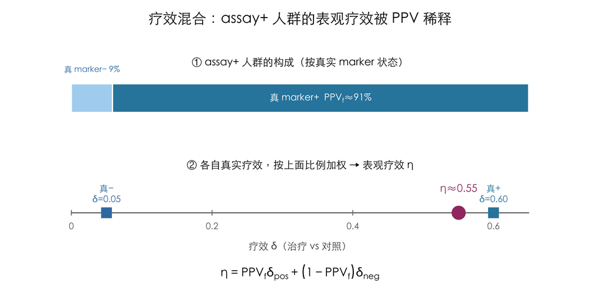

```r
par(family = "cjk", mar = c(0.5, 0.5, 3, 0.5))
plot(NA, xlim = c(0, 1), ylim = c(0, 1), axes = FALSE, xlab = "", ylab = "",
     main = "疗效混合：assay+ 人群的表观疗效被 PPV 稀释", cex.main = 1.45)
PPV <- 0.91; dpos <- 0.60; dneg <- 0.05; eta <- PPV*dpos + (1-PPV)*dneg
xof <- function(d) 0.08 + (d/0.65)*0.84
xL <- 0.08; xR <- 0.92; sp <- xL + (xR-xL)*(1-PPV)   # 左=marker−、右=marker+，与下方数轴同序
text(0.5, 0.93, "① assay+ 人群的构成（按真实 marker 状态）", cex = 1.05, font = 2)
rect(xL, 0.72, sp, 0.84, col = "#AED6F1", border = "white", lwd = 2)
rect(sp, 0.72, xR, 0.84, col = "#2E86AB", border = "white", lwd = 2)
text((xL+sp)/2, 0.90, sprintf("真 marker− %.0f%%", 100*(1-PPV)), col = "#3B7DB0", font = 2, cex = 0.82)
text((sp+xR)/2, 0.78, bquote(paste("真 marker+  ", PPV[f], "≈", .(round(100*PPV)), "%")), col = "white", font = 2, cex = 0.95)
text(0.5, 0.5, "② 各自真实疗效，按上面比例加权 → 表观疗效 η", cex = 1.05, font = 2)
segments(xof(0), 0.30, xof(0.65), 0.30, lwd = 2, col = "gray50")
for (d in c(0,0.2,0.4,0.6)) { segments(xof(d),0.29,xof(d),0.31,lwd=1.5,col="gray50"); text(xof(d),0.245,d,cex=0.9,col="gray40") }
text(0.5, 0.16, "疗效 δ（治疗 vs 对照）", cex = 1.0, col = "gray30")
points(xof(dneg), 0.30, pch = 15, col = "#3B7DB0", cex = 2.4)
points(xof(dpos), 0.30, pch = 15, col = "#2E86AB", cex = 2.4)
points(xof(eta),  0.30, pch = 19, col = "#A23B72", cex = 3.0)
text(xof(dneg), 0.38, sprintf("真−\nδ=%.2f", dneg), col = "#3B7DB0", font = 2, cex = 0.9)
text(xof(dpos), 0.38, sprintf("真+\nδ=%.2f", dpos), col = "#2E86AB", font = 2, cex = 0.9)
text(xof(eta),  0.40, sprintf("η≈%.2f", eta), col = "#A23B72", font = 2, cex = 1.05)
text(0.5, 0.05, expression(eta == PPV[f] * delta[pos] + (1 - PPV[f]) * delta[neg]), cex = 1.2)
```

PPV 越大（assay 越好），$\eta$ 越靠近 $\delta_{\text{pos}}$、稀释越少；反过来，assay 越差、混进的真阴性越多，表观疗效越被拖低。

下面把这套混合用三条独立的路各算一遍，看对不对得上——而且顺手把 $\eta$（CDx+）和它的孪生 $\theta$（CCD+）一起算，当场验证”换个 assay、同一台机器”（下面以 CDx 为例讲三条路，CCD 完全一样）：

- 混合公式：套上式 $PPV_f\,\delta_{\text{pos}}+(1{-}PPV_f)\,\delta_{\text{neg}}$，其中 $PPV_f$ 从模拟样本里数出来（`mean(sub$G==1)`，即”CDx 判阳的人里真 $G{=}1$ 的比例”）。
- 直接估计：完全不碰公式，在 CDx+ 这群人里直接量 $Y$ 的差——治疗组 $Y$ 均值 $-$ 对照组 $Y$ 均值（就是 `delta_hat`）。这正是真实试验会观测到的”表观疗效”本身。
- 闭式真值：就是前面那个算子 `true_delta_in_assay_pos()`——不抽样，先用贝叶斯从参数精确算出 $PPV_f=\dfrac{\text{sens}\cdot\text{prev}}{\text{sens}\cdot\text{prev}+(1{-}\text{spec})(1{-}\text{prev})}$（这里 sens/spec 取 CDx 的），再套同一条混合公式。

```r
pop <- generate_population(3e5, with_endpoint = TRUE)
mix_check <- function(assay_col, oc) {
  sub <- pop[pop[[assay_col]] == 1, ]
  ppv <- mean(sub$G == 1)                                # 从样本数出的 PPV
  c(PPV        = round(ppv, 4),
    `混合公式` = round(ppv*TRUTH$endpoint$delta_pos + (1-ppv)*TRUTH$endpoint$delta_neg, 4),
    `直接估计` = round(delta_hat(sub), 4),                # 只量 Y，不预设任何模型
    `闭式真值` = round(true_delta_in_assay_pos(oc), 4))   # 不抽样，从参数精确算
}
tab <- rbind(`η（FCD+ = CDx+）` = mix_check("CDx",  TRUTH$assays$CDx),
             `θ（CCD+）`        = mix_check("CCD1", TRUTH$assays$CCD))
ft_show(tab, title = "同一台机器换个 assay：η、θ 各自三条路都对齐", rowname = "人群疗效")
```

同一台机器换个 assay：η、θ 各自三条路都对齐

| 人群疗效 | PPV | 混合公式 | 直接估计 | 闭式真值 |
| --- | --- | --- | --- | --- |
| η（FCD+ = CDx+） | 0.9112 | 0.5512 | 0.5578 | 0.5508 |
| θ（CCD+） | 0.8717 | 0.5295 | 0.5304 | 0.5280 |

✓ 两行、各自三路对齐：$\eta$（CDx+）≈0.55、$\theta$（CCD+）≈0.53——CCD 比 CDx 略差、$PPV$ 稍低，混进的真阴性更多、疗效被稀释得更狠，完全在意料之中。这正是概念地基兑现成数字：$\eta$、$\theta$ 不是抽象记号，而是模拟世界里数得出、对得上的真实量。有个微妙点值得点破：混合公式和闭式真值其实都用了那条混合公式（只是 $PPV$ 一个来自样本、一个来自参数），它俩对上只说明”样本 PPV≈真 PPV”。真正独立的裁判是「直接估计」——它只老实量 $Y$、不预设任何混合模型；它也和闭式真值对上，才证明”assay+ 疗效 = 真+/真− 按 PPV 混合”这个模型本身没说错。η 和 θ 用的是同一个 `mix_check`，只换了 assay 列——框架的对称性，在代码里就是同一个函数。

这里有个容易滑过、却很关键的点。 这里的混合、以及后面 bridging 的搬运，本质是同一句话：合并人群的疗效 = 各子群疗效按人数占比加权平均。当疗效用的是均值差 $\delta$ 时，这句话是恒等式、永远成立——因为”一群人的平均值 = 各子群平均值按占比加权”本就是平均数的定义，两臂各自取平均再相减，这个加权关系原样传下来。

但”按占比加权平均”并非对任何疗效度量都成立——只在疗效是均值型（而非比值型）时才精确。 最典型的反例是 Cox 模型的风险比 HR：即便药在两个子群里 HR 都恰好等于 $0.6$，把两个 $0.6$ 按占比加权也得不到合并人群的 HR（合并后通常朝 $1$ 漂）。原因是比值不是期望、不服从”按占比加权”，这个性质叫不可塌缩 (non-collapsible)。所以本文统一用连续端点的均值差，是为了让搬运恒等式精确成立、教学干净；真实试验里疗效常报成 HR，这时”看似能线性搬运、其实得先换到可塌缩的尺度（均值差 / 某时点生存率差 / RMST）“本身就是 bridging 会踩的坑。完整展开见末章 「补充：为什么用连续端点」。

## 3.4 地基全景：一张图把三层与正交的治疗臂串起来

整章的量，串成一张图。两条线都从真相 $G$ 出发：往左，$G$ 被各 assay 有噪声地测量（每个 assay 一副 $sens/spec$），派生出 $PPV/NPV$、$PPA/NPA$、搬运权重 $p$；往右，$G$ 和随机的治疗臂 $T$ 正交地共同决定四格结局均值 $\mu_{TG}$，同列（同一 marker、沿 $T$）相减得两块积木 $\delta_{\text{pos}}$、$\delta_{\text{neg}}$。两条线在最底部汇合：任何 assay+ 人群的疗效，都是这两块积木、按左边那条线算出的 $PPV$ / $p$ 加权——这就是 $\eta$（FCD+）、$\theta$（CCD+），以及通向第 4 章 bridging 的 $\delta_{CDx}$。

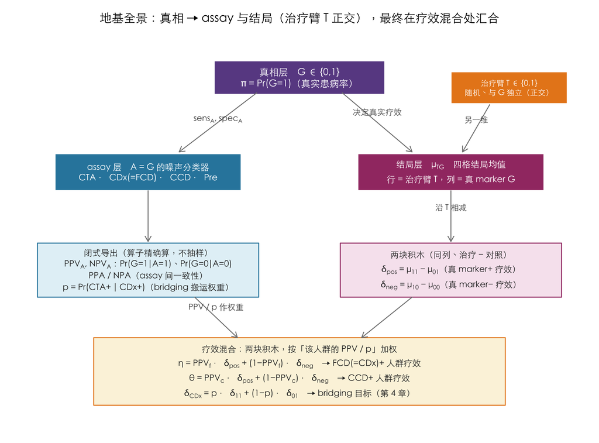

```r
par(family = "cjk", mar = c(0.5, 0.5, 3, 0.5))
plot(NA, xlim = c(0, 14), ylim = c(0, 11), axes = FALSE, xlab = "", ylab = "",
     main = "地基全景：真相 → assay 与结局（治疗臂 T 正交），最终在疗效混合处汇合",
     cex.main = 1.2)

# 多行框：每行可为普通字符串或 plotmath 表达式（下标走 X[sub]，与表/正文一致的真下标）
cellbox <- function(x, y, w, h, lines, fill, tcol, cex = 0.86, border = "white", lwd = 2) {
  rect(x-w/2, y-h/2, x+w/2, y+h/2, col = fill, border = border, lwd = lwd)
  n <- length(lines)
  ys <- y + (h/2 - 0.12) - (seq_len(n) - 0.5) * (h - 0.24) / n
  fnt <- if (identical(tcol, "white")) 2 else 1
  for (i in seq_len(n)) text(x, ys[i], lines[[i]], col = tcol, cex = cex, font = fnt)
}

# ① 真相层 G（根）
draw_box(7, 10.2, "真相层　G ∈ {0,1}\nπ = Pr(G=1)（真实患病率）", "#6A4C93", w = 4.4, h = 1.0, cex = 0.95)

# ② assay 层（G 的噪声分类器）＋ ③ 结局层 μ（G × T 四格）
draw_box(3.1, 7.4, "assay 层　A = G 的噪声分类器\nCTA · CDx(=FCD) · CCD · Pre", "#2E86AB", w = 4.8, h = 1.1, cex = 0.88)
cellbox(10.9, 7.4, 4.8, 1.1, list(
  expression(paste("结局层　", mu[TG], "　四格结局均值")),
  "行 = 治疗臂 T，列 = 真 marker G"), "#A23B72", "white", cex = 0.88)
draw_arr(5.9, 9.75, 3.9, 8.0, cex = 0.82); text(4.9, 8.95, expression(paste(sens[A], ", ", spec[A])), cex = 0.82, col = "gray30", font = 3)
draw_arr(8.1, 9.75, 9.9, 8.0, "决定真实疗效", cex = 0.82, adj_y = 0.30)

# ④ 治疗臂 T（正交轴）
draw_box(12.4, 9.9, "治疗臂 T ∈ {0,1}\n随机、与 G 独立（正交）", "#E8871E", w = 3.0, h = 0.95, cex = 0.78)
draw_arr(11.9, 9.4, 11.2, 8.0, "另一维", cex = 0.8, adj_y = 0.25)

# ⑤ assay 分支 → 闭式导出
cellbox(3.1, 4.5, 5.7, 1.6, list(
  "闭式导出（算子精确算，不抽样）",
  expression(paste(PPV[A], ", ", NPV[A], "：Pr(G=1|A=1)、Pr(G=0|A=0)")),
  "PPA / NPA（assay 间一致性）",
  "p = Pr(CTA+ | CDx+)（bridging 搬运权重）"), "#E3F1F7", "gray15", border = "#2E86AB", lwd = 1.6)
draw_arr(3.1, 6.85, 3.1, 5.35)

# ⑥ 结局分支 → 两块积木
cellbox(10.9, 4.5, 5.7, 1.6, list(
  "两块积木（同列、治疗 − 对照）",
  expression(paste(delta[pos], " = ", mu["11"], " − ", mu["01"], "（真 marker+ 疗效）")),
  expression(paste(delta[neg], " = ", mu["10"], " − ", mu["00"], "（真 marker− 疗效）"))),
  "#F7E6EF", "gray15", border = "#A23B72", lwd = 1.6)
draw_arr(10.9, 6.85, 10.9, 5.35, "沿 T 相减", cex = 0.8, adj_y = 0.25)

# ⑦ 汇合：疗效混合（PPV / p 当权重）
cellbox(7, 1.5, 10.6, 2.0, list(
  "疗效混合：两块积木，按「该人群的 PPV / p」加权",
  expression(paste(eta, " = ", PPV[f], " · ", delta[pos], " + (1−", PPV[f], ") · ", delta[neg], "　→ FCD(=CDx)+ 人群疗效")),
  expression(paste(theta, " = ", PPV[c], " · ", delta[pos], " + (1−", PPV[c], ") · ", delta[neg], "　→ CCD+ 人群疗效")),
  expression(paste(delta[CDx], " = p · ", delta["11"], " + (1−p) · ", delta["01"], "　→ bridging 目标（第 4 章）"))),
  "#FBF3DE", "gray15", cex = 0.86, border = "#E8871E", lwd = 1.6)
draw_arr(9.9, 3.7, 8.6, 2.5)                               # 积木 → 混合
draw_arr(4.3, 3.7, 5.4, 2.5, "PPV / p 作权重", cex = 0.82, adj_y = 0.30)  # 权重跨分支 → 混合
```

图里的量分三种身份，正对应本章”设参数 → 算真值 → 模拟对撞”的三步：设定——$\pi$、各 assay 的 $sens/spec$、$\delta_{\text{pos}}$、$\delta_{\text{neg}}$，是你在 `TRUTH` 里直接给的参数；闭式导出——$PPV/NPV$、$PPA/NPA$、$p$，以及 $\eta/\theta$ 的真值，由算子不抽样、纯从参数精确算；模拟估计——以上每个量在生成数据里数出的经验版。本章 §「生成器、真值算子与自洽验证」做的正是把后两者对撞、确认相等，DGP 才够格当”标准答案”。$T$ 与 $G$ 正交是关键：$T$ 随机分配、独立于 marker，所以 $\mu$ 才需要 $T$、$G$ 两个下标，而疗效永远是在某个 marker 分组内、沿 $T$ 相减得到的。

# 4 Bridging：缺失格与疗效搬运

地基搭好，先讲本文主角 bridging：自己试验里就有疗效数据（不管是 RCT 的臂间差还是单臂的应答率），难点是把它从”入组用的 CTA 定义的人群”搬到”最终 CDx 定义的人群”，而两者不重合、还缺了一整格数据。（第五章的 follow-on 是同一套骨架换一种缺失结构——自己不做疗效试验、改靠与已批准 CCD 的一致性间接搬运。）

## 4.1 为什么需要 bridging，怎么分步做

动机前面讲过：bridging 出现在最终 CDx 与 pivotal trial 入组 assay 不一致时。监管指导把它描述为：用原临床试验样本和预设统计分析计划比较 CTA 与候选 CDx，并据此把 CTA 的临床性能外推到最终 CDx；后续方法学工作进一步系统讨论了缺失样本、local test、pre-screening 和低阳性率 biomarker 等问题 (U.S. Food and Drug Administration 2016; Song et al. 2024)。

先说清这里 $\delta$ 的下标，别被第三章绊到。 第三章的 $\delta_{\text{pos}}/\delta_{\text{neg}}$ 按真实 marker 分组、只有一个标签；这里的 $\delta$ 带两位数字，但这两位是 (CTA 状态, CDx 状态)，不是 $\mu_{TG}$ 那种 (治疗臂 $T$, 真 marker $G$)。读法：$\delta_{ab}$ = 在”CTA$=a$ 且 CDx$=b$“这一格里的疗效（治疗 − 对照）——所以 $\delta_{11}$ 是 (CTA+ & CDx+)、$\delta_{01}$ 是 (CTA− & CDx+)。两点要记住：其一，$\delta$ 和 $\delta_{\text{pos}}$ 一样本身已经是臂间差、不带治疗臂下标，两位数字只标”落在哪个观察得到的格子”，跟 $T$ 无关（$T$ 已被”治疗 − 对照”这步吃掉）；其二，这里改按 CTA/CDx 分组、而非第三章的真 $G$，是因为真实试验里真 marker $G$ 看不到，只能按观察得到的 assay 判读来切人群。

进入”怎么做”，三步：

1. 一致性 (concordance)：用试验筛查/入组样本，估最终 CDx 与 CTA 的一致性（PPA/NPA）；由此得搬运权重 $p=\Pr(CTA{+}\mid CDx{+})$。
2. 疗效 (efficacy)：在观察得到的 (CTA+ & CDx+) 格子里估疗效 $\delta_{11}$，据此推 CDx+ 人群的临床性能 $\delta_{CDx}$（selection test 的关注量）。
3. 缺失格敏感性 (sensitivity — 结构性缺失)：(CTA− & CDx+) 那格试验里从没入组、$\delta_{01}$ 不可识别，用敏感性参数 $c$ 假设它（$\delta_{01}=c\,\delta_{11}$），并给出 $\delta_{CDx}$ 对 $c$ 的依赖。核心、必做。

此外还有一个可选、触发式的分析，跟第 3 步是两回事：

4. 缺失 CDx 结果的敏感性 (sensitivity — 样本可用性缺失，*optional*)：第 3 步缺的是”一整格人群从没入组”；这一步缺的是”入组了、但个别样本拿不到 / 样本不足 / CDx 结果 invalid/未测”——是测量层面的缺失。做法：先量缺失/无效率，只有超过阈值（如 >10%）才触发在 MAR（随机缺失）假设下做多重插补、重估一致性与疗效；不超阈值就不做。

（标准 bridging 的结构性缺失就第 3 步这一处、一个 $c$；末章「进阶」里 pre-screening、多 CTA 会引入更多结构性缺失格，第 3 步那类敏感性就要做多份。第 4 步则始终是那个独立的、可选的测量缺失分析。本文 worked example 两步都走：第 3 步见「worked：三步在 DGP 上走一遍」，第 4 步——含插补的内部机制、MAR 与 MNAR 的后果——见「第 4 步：入组了，却没有 CDx 判读」及随后两节。）操作上，用最终 CDx 重测可用筛查样本，尽量含 CTA− 筛查样本和全部 CTA+ 入组样本（富集设计下尤其重要）。

## 4.2 标准 bridging：缺失结构

问题：CDx+ 人群疗效 $\delta_{CDx}$ 想估，可里面一整块（CTA−/CDx+）试验里根本没人——缺的这块怎么补？ 富集设计只入组 CTA+；回溯性贴 CDx 后，CTA−/CDx+ 亚组未观察到：

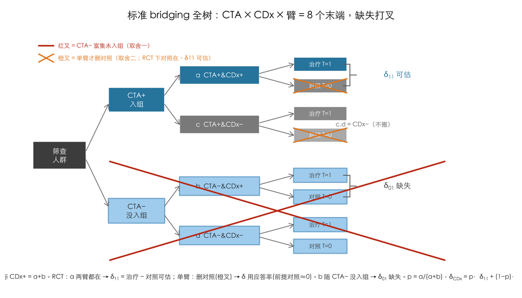

```r
par(family = "cjk", mar = c(0.5, 0.5, 3, 0.5))
plot(NA, xlim = c(0, 16), ylim = c(-0.5, 7.4), axes = FALSE, xlab = "", ylab = "",
     main = "标准 bridging 全树：CTA × CDx × 臂 = 8 个末端，缺失打叉", cex.main = 1.2)
lb <- "#AED6F1"; lbb <- "#7FB3D5"                                  # 未入组：淡蓝 + 深边
xm <- function(x, y, col, hw = 0.9, hh = 0.23) {                    # 叉：标"不存在"
  segments(x-hw, y-hh, x+hw, y+hh, col = col, lwd = 2.4); segments(x-hw, y+hh, x+hw, y-hh, col = col, lwd = 2.4) }
arm <- function(y, col, tx) draw_box(10.0, y, tx, col, w = 1.8, h = 0.46, cex = 0.72,
  txt = if (identical(col, lb)) "gray30" else "white", border = if (identical(col, lb)) lbb else "white")
draw_box(1.2, 3.65, "筛查\n人群", "gray30", w = 1.8, h = 0.9, cex = 0.85)
# ① 先按 CTA 分（入组用）
draw_box(3.8, 5.45, "CTA+\n入组", "#2E86AB", w = 1.9, h = 0.8, cex = 0.85)
draw_box(3.8, 1.85, "CTA−\n没入组", lb, w = 1.9, h = 0.8, cex = 0.85, txt = "gray20", border = lbb)
draw_arr(2.1, 3.8, 2.85, 5.3); draw_arr(2.1, 3.5, 2.85, 2.0)
# ② 再回贴 CDx → 四格 a,b,c,d
draw_box(6.6, 6.25, bquote(paste(bold("a"), "  CTA+&CDx+")), "#2E86AB", w = 2.7, h = 0.6, cex = 0.8)
draw_box(6.6, 4.65, bquote(paste(bold("c"), "  CTA+&CDx−")), "gray55", w = 2.7, h = 0.6, cex = 0.8)
draw_box(6.6, 2.65, bquote(paste(bold("b"), "  CTA−&CDx+")), lb, w = 2.7, h = 0.6, cex = 0.8, txt = "gray20", border = lbb)
draw_box(6.6, 1.05, bquote(paste(bold("d"), "  CTA−&CDx−")), lb, w = 2.7, h = 0.6, cex = 0.8, txt = "gray20", border = lbb)
draw_arr(4.75, 5.6, 5.25, 6.25); draw_arr(4.75, 5.3, 5.25, 4.65)
draw_arr(4.75, 2.0, 5.25, 2.65); draw_arr(4.75, 1.7, 5.25, 1.05)
# ③ 每格再分治疗 / 对照 → 8 个末端
arm(6.6, "#2E86AB", "治疗 T=1"); arm(5.9, "gray60", "对照 T=0")
arm(5.0, "gray60", "治疗 T=1"); arm(4.3, "gray72", "对照 T=0")
arm(3.0, lb, "治疗 T=1"); arm(2.3, lb, "对照 T=0")
arm(1.4, lb, "治疗 T=1"); arm(0.7, lb, "对照 T=0")
draw_arr(7.95, 6.3, 9.1, 6.6); draw_arr(7.95, 6.2, 9.1, 5.9)
draw_arr(7.95, 4.7, 9.1, 5.0); draw_arr(7.95, 4.6, 9.1, 4.3)
draw_arr(7.95, 2.7, 9.1, 3.0); draw_arr(7.95, 2.6, 9.1, 2.3)
draw_arr(7.95, 1.1, 9.1, 1.4); draw_arr(7.95, 1.0, 9.1, 0.7)
brace(11.0, 5.9, 6.6); text(12.6, 6.25, bquote(paste(delta[11], " 可估")), col = "#2E86AB", cex = 0.9, font = 2)
brace(11.0, 2.3, 3.0); text(12.6, 2.65, bquote(paste(delta["01"], " 缺失")), col = "gray30", cex = 0.9, font = 2)
text(11.5, 4.65, "c,d = CDx−（不搬）", col = "gray45", cex = 0.75, font = 3)
segments(2.9, 0.25, 14.2, 3.45, col = "#C73E1D", lwd = 3); segments(2.9, 3.45, 14.2, 0.25, col = "#C73E1D", lwd = 3)  # 红叉：CTA− 整支
xm(10.0, 5.9, "#E8871E"); xm(10.0, 4.3, "#E8871E")                  # 橙叉：单臂才删对照（CTA+ 支的对照 T=0）
segments(0.5, 7.2, 1.0, 7.2, col = "#C73E1D", lwd = 3); text(1.15, 7.2, "红叉 = CTA− 富集未入组（取舍一）", col = "#C73E1D", cex = 0.72, font = 2, adj = 0)
xm(0.75, 6.8, "#E8871E", 0.25, 0.13); text(1.15, 6.8, "橙叉 = 单臂才删对照（取舍二；RCT 下对照在、δ11 可估）", col = "#E8871E", cex = 0.72, font = 2, adj = 0)
text(8, -0.3, expression(paste("目标 CDx+ = a+b。RCT：a 两臂都在 → ", delta[11], " = 治疗 − 对照可估；单臂：删对照(橙叉) → δ 用应答率(前提对照≈0)。b 随 CTA− 没入组 → ", delta["01"], " 缺失。p = a/(a+b)，", delta[CDx], " = p·", delta[11], " + (1−p)·", delta["01"])),
     col = "gray20", cex = 0.76, font = 2)
```

$$\delta_{CDx} = p\,\delta_{11} +
(1-p)\,\delta_{01},\qquad p=\Pr(CTA{+}\mid CDx{+})$$

- $\delta_{11}$：(CTA+ & CDx+) 疗效——观察到。这里默认 RCT：CTA+ 入组者被随机分到治疗 / 对照，所以 (CTA+ & CDx+) 这格里两个臂都在，$\delta_{11}=$ 治疗 − 对照直接量得到（若改单臂设计则没有对照臂，“疗效”改用单臂应答率、不是臂差）。$\delta_{01}$：(CTA− & CDx+) 疗效——缺失，因为 CTA− 整支富集设计里没入组。
- 这是把 CDx+ 人群按 CTA 状态劈开的全期望恒等式。$p$ 可估，$\delta_{01}$ 只能靠假设/敏感性分析。
- 和 §地基「疗效混合」是同一套积木（$\delta_{\text{pos}}=\mu_{11}-\mu_{01}$、$\delta_{\text{neg}}=\mu_{10}-\mu_{00}$，就是地基那两块）：$\delta_{11}$、$\delta_{01}$ 各自也都是 $\delta_{\text{pos}}$、$\delta_{\text{neg}}$ 按各自格子 PPV 混出来的（$\delta_{01}$ 那格 PPV 更低、混进更多真−，所以 $\delta_{01}<\delta_{11}$，这正是后面取 $c=\delta_{01}/\delta_{11}\in(0,1)$ 的由来）。区别只在：那里按看不到的真 $G$ 分（需参考标准），这里改按观察得到的 CTA 分。

“臂差 vs 单臂应答率” 上面 $\delta_{11}=$ 治疗 − 对照，是个臂间差（对照差, contrast）——要有对照臂，答的是”用药比不用好多少”；对照替你扣掉了疾病自然史 / 安慰剂那一部分，所以这个差能干净地归因于药。单臂应答率（如 ORR，objective response rate，客观缓解率）没有对照，只在治疗组里量”缓解”的比例——是个绝对水平（level），答的是”治了有多少人缓解”；它扣不掉自然史，得拿历史 / 预设阈值当参照。单臂之所以立得住，靠的是”肿瘤不会自己缩、客观缓解可归因于药”（何时能单臂、历史对照的偏倚，详见 §「取舍二」）。

为什么单臂”只量治疗组”也能当疗效？把”臂”这一维显式写出来就清楚了（平时省掉、一滑而过，反而糊）。严格讲，每个格子里有两个臂均值，用一个带治疗臂下标的记号：$\mu_{T;\,11}$ = 治疗臂 $T\in\{1,0\}$、在 (CTA+ & CDx+) 格里的结局均值。于是臂差 $\delta_{11}=\mu_{1;11}-\mu_{0;11}$（治疗 − 对照，都在这一格）。平时把 $T$ 这维省掉、直接写 $\delta_{11}$，是因为差分已经把它吃掉——但省掉不等于不存在，对照项 $\mu_{0;11}$ 一直在那儿。

单臂设计里没有对照臂，量到的只有 $\mu_{1;11}$（治疗组的应答水平）。它能顶替疗效，靠的正是一个假设：对照项 $\mu_{0;11}\approx 0$——ORR 这类客观缓解终点，不治疗几乎无人自发缓解（肿瘤不自己缩），所以 $\delta_{11}=\mu_{1;11}-\mu_{0;11}\approx\mu_{1;11}$，“治疗组应答率”就≈“臂差”。这个假设不写出来就滑过去了，其实是单臂能成立的关键前提。（本文 DGP 恰好也把对照臂均值设成 $0$——$\mu_{01}=\mu_{00}=0$，见地基——所以那里 $\delta_{\text{pos}}=\mu_{11}$、$\delta_{\text{neg}}=\mu_{10}$，治疗组水平直接就等于疗效，与单臂同构。）

一句话对比：臂差是”相对某对照的差值”，应答率是”治疗组里的绝对水平”（后者当疗效用，前提是对照水平≈0）。但对 bridging 而言两者是一回事：应答率 = “是否缓解”这个 $0/1$ 变量的均值，和均值差一样属均值型、可按人数占比线性混合——所以把本章的 $\delta$ 一律替换成 ORR，搬运恒等式 $\delta_{CDx}=p\,\delta_{11}+(1-p)\,\delta_{01}$ 照样精确成立、公式一个都不用改。唯一不能这样换的是比值型的 HR（风险比不可塌缩，混合会偏，见末章 「补充：为什么用连续端点」）。

CDx × CTA 的 2×2 一致性表——格里 $a,b,c,d$ 是落入该格的病人数（样本数），不是概率：如 $a$ = 既 CTA+ 又 CDx+ 的人数、$d$ = 既 CTA− 又 CDx− 的人数，四格加起来 = 总样本量。

CDx × CTA 2×2 一致性表

|  | CTA+ | CTA- |
| --- | --- | --- |
| CDx+ | a | b |
| CDx- | c | d |

两个一致率直接从表读出（行 = CDx，列 = CTA）：

$$PPA=\Pr(CDx{+}\mid
CTA{+})=\frac{a}{a+c},\qquad NPA=\Pr(CDx{-}\mid
CTA{-})=\frac{d}{b+d}$$

即 PPA 是 $CTA{+}$ 那列里 $CDx{+}$ 的比例、NPA 是 $CTA{-}$ 那列里 $CDx{-}$ 的比例。还有第三个常用指标 OPA（overall percent agreement，总体一致率）——两检测判读完全一致的比例：

$$OPA=\Pr(CDx{=}CTA)=\frac{a+d}{a+b+c+d}$$

但 OPA 由患病率主导（把 PPA、NPA 按边际比例混成一个数），某一类占绝大多数时会虚高，所以监管一致性以 PPA、NPA 分开报为主、OPA 只作总览。本文的搬运公式用 PPA/NPA 加权重 $p$，不依赖 OPA——列出只为记号完整。

把 $a,b,c,d$ 和疗效 $\delta$ 对上（这里最容易晕）。 是同一张 CTA×CDx 网格、两个层：$a,b,c,d$ 数的是人数（谁落哪格），$\delta$ 是那格里的疗效（治疗 − 对照的 $Y$ 均值差）。把疗效层也摆成同布局的 2×2（行 = CDx、列 = CTA，和上面计数表一格对一格）：

同格的疗效 δ（下标 = CTA,CDx；与上表 a,b,c,d 一格对一格）

|  | CTA+ | CTA- |
| --- | --- | --- |
| CDx+ | δ11 | δ01 |
| CDx- | δ10 | δ00 |

一格对一格：人数 $a$ 那格的疗效是 $\delta_{11}$、$b$ 格是 $\delta_{01}$、$c$ 格是 $\delta_{10}$、$d$ 格是 $\delta_{00}$。bridging 只搬 CDx+ 那一行（$\delta_{11}$、$\delta_{01}$）：$\delta_{11}$（配人数 $a$）观察得到、$\delta_{01}$（配人数 $b$）缺失。按人数加权就是搬运公式——

$$\delta_{CDx}=\frac{a\,\delta_{11}+b\,\delta_{01}}{a+b}=p\,\delta_{11}+(1-p)\,\delta_{01},\qquad
p=\frac{a}{a+b}=\Pr(CTA{+}\mid CDx{+}).$$

（CDx− 行的 $\delta_{10}$、$\delta_{00}$ 不是搬运目标，本文不用。）

Bayes 估 $p=\Pr(CTA{+}\mid CDx{+})$：$p=\dfrac{PPA\cdot prev}{PPA\cdot prev+(1{-}NPA)(1{-}prev)}$，其中 $prev=\Pr(CTA{+})$ 须对应意向使用人群。下面核对这条 Bayes 式与直接估计一致：

```r
PPA_t <- 0.90; NPA_t <- 0.85; prev <- 0.30; n <- 1e4
a <- n*prev*PPA_t; b <- n*(1-prev)*(1-NPA_t)   # 用设定的 PPA/NPA/prev 造一张表
ft_show(data.frame(`p（Bayes 式）` = round((PPA_t*prev)/(PPA_t*prev+(1-NPA_t)*(1-prev)), 4),
           `p（直接从表）` = round(a/(a+b), 4), check.names = FALSE),
        title = "Bayes 估 p = 直接从表算")
```

Bayes 估 p = 直接从表算

| p（Bayes 式） | p（直接从表） |
| --- | --- |
| 0.72 | 0.72 |

## 4.3 worked：三步在 DGP 上走一遍（一致性 → 疗效 → 敏感性）

把 §4.1 的三步在已知真相的世界里逐一跑通，每步都从模拟数据估出、再和闭式真值对撞——看清楚哪些量数据能给、最终 $\delta_{CDx}$ 到底卡在哪一步的假设上。

步骤 1 · 一致性 → 搬运权重 $p$。 用一份代表性筛查样本（CTA、CDx 都测、含 CTA−、未富集）估 PPA/NPA，再 Bayes 得 $p=\Pr(CTA{+}\mid CDx{+})$：

```r
scr <- generate_population(3e5)                               # 代表性筛查样本（未富集，含 CTA−）
PPA_hat <- mean(scr$CDx[scr$CTA==1]==1)                       # Pr(CDx+|CTA+)
NPA_hat <- mean(scr$CDx[scr$CTA==0]==0)                       # Pr(CDx−|CTA−)
p_hat   <- mean(scr$CTA[scr$CDx==1]==1)                       # Pr(CTA+|CDx+) = 搬运权重
tc <- true_concordance(TRUTH$assays$CTA, TRUTH$assays$CDx)
ft_show(data.frame(
  `量` = c("PPA_{CTA,CDx}", "NPA_{CTA,CDx}", "p = Pr(CTA+|CDx+)"),
  `估计` = round(c(PPA_hat, NPA_hat, p_hat), 4),
  `真值` = round(c(tc[["PPA"]], tc[["NPA"]], true_p_cta_given_cdx()), 4),
  check.names = FALSE), title = "步骤 1：一致性与搬运权重 p —— 估计 vs 真值")
```

步骤 1：一致性与搬运权重 p —— 估计 vs 真值

| 量 | 估计 | 真值 |
| --- | --- | --- |
| PPACTA,CDx | 0.7558 | 0.7540 |
| NPACTA,CDx | 0.9005 | 0.8993 |
| p = Pr(CTA+\|CDx+) | 0.7855 | 0.7829 |

步骤 2 · 疗效 → 观察格 $\delta_{11}$。 富集试验只入组 CTA+，在观察得到的 (CTA+ & CDx+) 格里直接估 $\delta_{11}$（治疗 − 对照）：

```r
trial <- generate_population(2e5, with_endpoint = TRUE)       # 富集试验（分析只用 CTA+）
d11_hat <- delta_hat(subset(trial, CTA==1 & CDx==1))          # 观察格疗效
big2 <- generate_population(3e6, with_endpoint = TRUE)        # god 视角：算真值用
true_d11 <- delta_hat(subset(big2, CTA==1 & CDx==1))
ft_show(data.frame(`δ_{11} 估计` = round(d11_hat,4), `δ_{11} 真值` = round(true_d11,4),
  check.names = FALSE), title = "步骤 2：观察格 (CTA+ & CDx+) 疗效 δ_{11} —— 估计 vs 真值")
```

步骤 2：观察格 (CTA+ & CDx+) 疗效 δ11 —— 估计 vs 真值

| δ11 估计 | δ11 真值 |
| --- | --- |
| 0.6103 | 0.5952 |

步骤 3 · 缺失格敏感性 → $\delta_{CDx}$。 (CTA− & CDx+) 那格没人、$\delta_{01}$ 测不到，用敏感性参数 $c=\delta_{01}/\delta_{11}$ 顶上，于是 $\delta_{CDx}=(p+(1-p)c)\,\delta_{11}$。把步骤 1、2 估到的 $p$、$\delta_{11}$ 代进去、扫 $c$；再用 god 视角的真 $c$ 验证能否还原真 $\delta_{CDx}$：

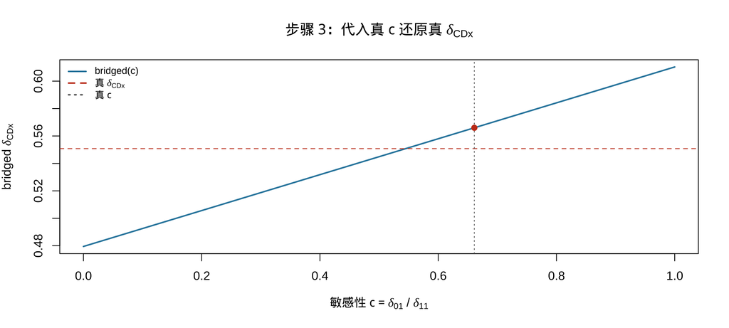

```r
true_d01 <- delta_hat(subset(big2, CTA==0 & CDx==1))          # god 视角：缺失格真疗效
true_dCDx <- true_delta_in_assay_pos(TRUTH$assays$CDx); c_true <- true_d01/true_d11
c_seq <- seq(0, 1, 0.02)
plot(c_seq, (p_hat+(1-p_hat)*c_seq)*d11_hat, type = "l", lwd = 2, col = "#2E86AB",
     xlab = expression(paste("敏感性 c = ", delta["01"], " / ", delta["11"])),
     ylab = expression(paste("bridged ", delta[CDx])),
     main = expression(paste("步骤 3：代入真 c 还原真 ", delta[CDx])))
abline(h = true_dCDx, lty = 2, col = "#C73E1D"); abline(v = c_true, lty = 3, col = "gray40")
points(c_true, (p_hat+(1-p_hat)*c_true)*d11_hat, pch = 19, col = "#C73E1D")
legend("topleft", legend = expression(paste("bridged(c)"), paste("真 ", delta[CDx]), paste("真 c")),
       col = c("#2E86AB","#C73E1D","gray40"), lty = c(1,2,3), lwd = 2, bty = "n", cex = 0.8)
```

```r
ft_show(data.frame(`δ_{01} 真值` = round(true_d01,4), `c 真值` = round(c_true,4),
  `δ_{CDx}（代入真 c）` = round((p_hat+(1-p_hat)*c_true)*d11_hat,4), `δ_{CDx} 真值` = round(true_dCDx,4),
  check.names = FALSE), title = "步骤 3：代入真 c 还原真 δ_{CDx}")
```

步骤 3：代入真 c 还原真 δCDx

| δ01 真值 | c 真值 | δCDx（代入真 c） | δCDx 真值 |
| --- | --- | --- | --- |
| 0.3935 | 0.6611 | 0.566 | 0.5508 |

## 4.4 第 4 步：入组了，却没有 CDx 判读

前三步处理的缺失是一整格人群缺席。这一节是另一种缺失：人在试验里，CDx 那一格却是空的——样本没采到、采到了量不足、DNA 降解让判读成 INVALID、或者根本没送测。这就是 §4.1 列的第 4 步：独立于第 3 步、可选、触发式。临床 bridging 的方法学综述也把 sample retainment / missing data 单列为核心难点 (Song et al. 2024)。

本节的疗效改用单臂应答率（记 $R_1$ = 观察格 CTA+ & CDx+ 里的应答率，例如 CR/CRh 率），因为真实的 CDx 敏感性分析多半长这样。搬运恒等式一个字都不用改（§4.2 已说明率是均值型、可线性混合）：

$$R_{CDx}=p\,R_1+(1-p)\,R_2,\qquad
R_2=c\,R_1 \quad\Longrightarrow\quad
R_{CDx}=\bigl(p+(1-p)c\bigr)R_1$$

### 4.4.1 两种缺失，差在有没有可借的信息

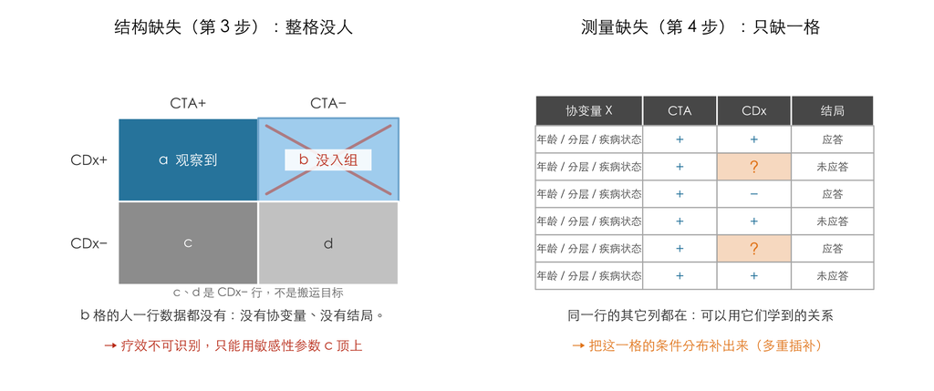

```r
par(family = "cjk", mfrow = c(1, 2), mar = c(0.6, 0.6, 3.0, 0.6))
lb <- "#AED6F1"; lbb <- "#7FB3D5"; org <- "#E8871E"

## 左：结构缺失——整格没人
plot(NA, xlim = c(0, 10), ylim = c(0, 8), axes = FALSE, xlab = "", ylab = "",
     main = "结构缺失（第 3 步）：整格没人", cex.main = 1.15)
text(3.9, 7.0, "CTA+", col = "gray25", font = 2, cex = 0.95)      # 列头
text(7.3, 7.0, "CTA−", col = "gray25", font = 2, cex = 0.95)
text(1.95, 5.5, "CDx+", col = "gray25", font = 2, cex = 0.95, adj = 1)   # 行头
text(1.95, 3.3, "CDx−", col = "gray25", font = 2, cex = 0.95, adj = 1)
rect(2.2, 4.4, 5.6, 6.6, col = "#2E86AB", border = "white", lwd = 2)
rect(5.6, 4.4, 9.0, 6.6, col = lb, border = lbb, lwd = 2)
rect(2.2, 2.2, 5.6, 4.4, col = "gray62", border = "white", lwd = 2)
rect(5.6, 2.2, 9.0, 4.4, col = "gray80", border = "white", lwd = 2)
segments(5.8, 4.6, 8.8, 6.4, col = adjustcolor("#C73E1D", 0.5), lwd = 3)  # 叉先画，文字压上面
segments(5.8, 6.4, 8.8, 4.6, col = adjustcolor("#C73E1D", 0.5), lwd = 3)
text(3.9, 5.5, "a  观察到", col = "white", font = 2, cex = 0.95)
rect(6.25, 5.22, 8.35, 5.78, col = adjustcolor("white", 0.88), border = NA)   # 叉上垫白底
text(7.3, 5.5, "b  没入组", col = "#C73E1D", font = 2, cex = 0.95)
text(3.9, 3.3, "c", col = "white", font = 2, cex = 0.95)
text(7.3, 3.3, "d", col = "gray25", font = 2, cex = 0.95)
text(5.6, 2.0, "c、d 是 CDx− 行，不是搬运目标", col = "gray45", cex = 0.78, font = 3)
text(5.0, 1.4, "b 格的人一行数据都没有：没有协变量、没有结局。", col = "gray20", cex = 0.9, font = 2)
text(5.0, 0.6, "→ 疗效不可识别，只能用敏感性参数 c 顶上", col = "#C73E1D", cex = 0.9, font = 2)

## 右：测量缺失——行都在，只缺一格
plot(NA, xlim = c(0, 10), ylim = c(0, 8), axes = FALSE, xlab = "", ylab = "",
     main = "测量缺失（第 4 步）：只缺一格", cex.main = 1.15)
hdr <- c("协变量 X", "CTA", "CDx", "结局")
xs  <- c(1.0, 3.6, 5.4, 7.2); xe <- c(3.6, 5.4, 7.2, 9.2)
for (j in seq_along(hdr)) {
  rect(xs[j], 6.4, xe[j], 7.2, col = "gray35", border = "white", lwd = 1.6)
  text((xs[j] + xe[j])/2, 6.8, hdr[j], col = "white", font = 2, cex = 0.82)
}
cdx_val <- c("+", "?", "−", "+", "?", "+")
for (i in 1:6) {
  yb <- 6.4 - i * 0.72; yt <- yb + 0.72
  gone <- cdx_val[i] == "?"
  for (j in seq_along(hdr)) {
    fill <- if (j == 3 && gone) adjustcolor(org, 0.28) else "white"
    rect(xs[j], yb, xe[j], yt, col = fill, border = "gray70", lwd = 1.2)
  }
  text((xs[1] + xe[1])/2, (yb + yt)/2, "年龄 / 分层 / 疾病状态", col = "gray30", cex = 0.72)
  text((xs[2] + xe[2])/2, (yb + yt)/2, "+", col = "#2E86AB", font = 2, cex = 0.95)
  text((xs[3] + xe[3])/2, (yb + yt)/2, cdx_val[i],
       col = if (gone) org else "#2E86AB", font = 2, cex = if (gone) 1.15 else 0.95)
  text((xs[4] + xe[4])/2, (yb + yt)/2, if (i %% 2) "应答" else "未应答", col = "gray30", cex = 0.72)
}
text(5.0, 1.4, "同一行的其它列都在：可以用它们学到的关系", col = "gray20", cex = 0.9, font = 2)
text(5.0, 0.6, "→ 把这一格的条件分布补出来（多重插补）", col = org, cex = 0.9, font = 2)
```

分水岭就是”有没有可借的信息”。 结构缺失那格的人从没入组，数据里一行都没有，$\delta_{01}$（率版本的 $R_2$）不可识别，只能靠 $c$。测量缺失的人整行都在——人口学、临床分层、CTA 判读、结局全有，只缺 CDx 一格；于是可以用”有判读的人”身上学到的关系，把这一格补上。

插补补的是分布，不是真值。 谁也不知道那个人到底是 CDx+ 还是 CDx−；能做的是按条件概率抽一个，抽很多次（多重插补），看结论在这些抽法之间晃多少。晃动幅度本身就是答案的一部分。这正是多重插补相对于单值填补的关键：让缺失值不确定性进入最终推断 (Rubin 1987; Little and Rubin 2019)。

### 4.4.2 触发：先量缺失率，超过阈值才做

实务顺序是：按队列量”缺失或无效”的比例 → 超过阈值（常取 10%）才启动多重插补，并在观察值 + 插补值的合并数据上重估一致性与疗效；不超阈值就用有判读的人直接分析。阈值不是统计定理，是工作量与风险的折衷；把它写进 SAP 的作用是在看到结果之前就定好做不做，避免”结果不好看才补一个敏感性分析”。

### 4.4.3 三档缺失机制

记 $R$ 为缺失指示（$R=1$ 表示这个人的 CDx 判读缺失），$Z$ 为待缺失的 CDx 判读，$X$ 为观测到的协变量：

缺失机制三档（R = 缺失指示，Z = 待缺失的 CDx 判读，X = 观测协变量）

| 机制 | 定义 | 读法 | 丢弃缺失者 | MAR 插补能修吗 |
| --- | --- | --- | --- | --- |
| MCAR | Pr(R=1 \| Z, X) = Pr(R=1) | 缺失与任何东西无关 | 无偏 | 不必修 |
| MAR | Pr(R=1 \| Z, X) = Pr(R=1 \| X) | 缺不缺可以看 X 决定；X 给定之后，不再多看一眼那个要缺的判读 | 一般有偏（X 的分布被筛过） | 能修（前提：X 进了插补模型） |
| MNAR | Pr(R=1 \| Z, X) 仍依赖 Z | 缺不缺还取决于判读本身（如 CDx− 的样本更容易 invalid） | 有偏 | 修不掉 |

**MAR** 是假设，不是可检验的事实。 缺失值那部分不出现在观测数据的似然里，所以一个 MAR 模型和某个 MNAR 模型可以对观测数据给出完全相同的拟合——数据分不开它们。这样看，第 4 步和第 3 步同属”靠假设”，区别在假设的位置和成本：$c$ 是一个完全没有数据支撑的旋钮，MAR 则借到了 $X$ 的信息，还能把插补带来的变异量出来。因此主分析必须陈述可识别假设，并用敏感性分析探索不可检验部分 (National Research Council 2010; Little and Rubin 2019)。

机制往哪偏也可以推：样本量不足、肿瘤含量低导致的判读无效，很可能与 marker 状态本身相关——那就落在 MNAR 一档。本节最后会把这种情形的后果量出来。

### 4.4.4 插补模型放哪些变量

实务做法：人口学 + 临床基线（年龄、性别、种族、风险分层、疾病状态）。两个刻意的选择：

1. 不放先前的 CDx 判读。 那等于把待插补量的一个近似副本喂进模型，插补值会近乎复制它；一致性表随之被这份人造相关撑起来，PPA 和权重 $p$ 抬高，敏感性分析看不出缺失的影响。
2. CTA 判读放不放，是一个有方向的取舍。 放进去是 MAR 的正统做法——凡与缺失、或与待插补量相关的观测变量都该进模型，这样才修得掉偏倚。不放，插补分布就向”含大量 CTA− 阴性材料的整体”回归，插出的 CDx 偏阴，PPA 与 $p$ 偏低，结论偏保守。下面的 worked example 把两条路的偏倚各自量出来。

协变量本身若有零星缺失，实务里常直接填一个”未报告”类别（分类变量）或中位数（连续变量），不再单独建一层插补模型——“未报告”在基线表里本来就是一个真实类别。

### 4.4.5 CTA− 那一列不插补

缺失发生在入组的 CTA+ 人群；一致性表里的 CTA− 一列通常来自外部阴性材料（专为估 NPA 收集、判读齐全）。这些人要留在模型框里，因为 NPA 得靠它们；但不给它们插补——给一列本来齐全的判读插补，等于直接改写 NPA。真有 CTA− 个体缺 CDx 判读，做法是剔除并把剔除数报出来。

## 4.5 一次插补 = 两次抽样

`mice` 的 `logreg`（logistic regression 插补）核心只有三步：

$$\text{① 拟合（只用有判读的人）：}\quad
\operatorname{logit}\Pr(\text{CDx}{=}1\mid
X)=X^{\top}\hat\beta$$

$$\text{② 抽系数：}\quad
\beta^{*}=\hat\beta+L^{\top}z,\qquad
L^{\top}L=\widehat{\operatorname{Cov}}(\hat\beta),\quad z\sim
N(0,I)$$

$$\text{③ 抽判读：}\quad
\pi_i=\operatorname{expit}\!\bigl(x_i^{\top}\beta^{*}\bigr),\qquad
\text{CDx}_i^{\text{imp}}=\mathbf{1}\{u_i\le\pi_i\},\quad u_i\sim
U(0,1)$$

两次抽样各管一件不确定性：② 管参数不确定性——完整案例就那么多人，回归系数本身是估出来的；③ 管个体残差不确定性——同样 $\pi=0.7$ 的两个人，一个可以是阳、一个可以是阴。少任何一步都会把不确定性做小：只做 ③（把 $\hat\beta$ 当真值，文献里叫 improper imputation）低估插补方差；两步都不做、直接填 $\pi>0.5$ 的那一类，则所有插补数据集完全相同，多重插补退化成单值填补，跨插补方差是 0。三种填法的差别下面会量。

### 4.5.1 插补值进入这条链的三个位置

每个完整数据集都要把第 1–3 步重跑一遍。插补的判读不是只改一个计数，它同时进三处：

1. 2×2 表 → PPA、NPA → 经 Bayes 得权重 $p$；
2. $R_1$ 的分母：谁算进双阳格（CTA+ & CDx+）；
3. $R_1$ 的分子：这些人应答与否（结局是观察到的，但算不算进分子取决于插补的判读）。

三处的偏倚方向可以互不相同，净效应要算——这也是为什么不能只看 PPA 一处就下结论。

### 4.5.2 $c=1$ 那一行是个恒等式

$$R_{CDx}(c)=p\,R_1+(1-p)\,c\,R_1
\quad\xrightarrow{\ c=1\ }\quad p\,R_1+(1-p)\,R_1=R_1$$

$p$ 整个消掉：$c=1$ 那一行就是双阳应答率本身，与主分析对得上，可当交叉校验读。反过来说，若敏感性分析只做 $c=1$ 一档，一致性那一整套（PPA、NPA、$p$ 以及 $p$ 的方差）算了也会被代数消掉——不是算错，是这一档的必然结果。

### 4.5.3 m 取多大，取决于怎么汇总

Rubin 规则下 $m=20\sim50$ 通常已足够（相对效率 $(1+\gamma/m)^{-1}$，$\gamma$ 为缺失信息比例；具体所需次数仍取决于 FMI 与目标精度）(Rubin 1987)。而实务表格常用五数概括报这 $m$ 个估计（Min/Q1/中位/均值/Q3/Max），那就得把 $m$ 提到几百上千：四分位数很快稳住，而 Min、Max 是极值统计量，$m$ 越大越往外走、不收敛。所以 $m=1000$ 服务的是”极值那两列别乱跳”；即便如此，那两列的读法也只能是”这 1000 次里最坏/最好的一次”，不是界限。下面把这条漂移画出来。

## 4.6 worked：缺失 CDx 的插补在 DGP 上走一遍

在已知真相的世界里，“如果没有缺失”这个对照是能拿到的——真实数据里永远拿不到。整节的验证策略就是拿它当基准：全数据估计 vs 丢弃缺失者 vs 两种插补，看谁回得去。

先给这一节的 DGP 加两样东西：与真 marker 相关的基线协变量（插补模型要用），和一个二值应答（单臂率）。assay 参数、患病率、疗效都沿用 `TRUTH`，不新设。

```r
gen_mi <- function(n, truth = TRUTH) {
  G  <- rbinom(n, 1, truth$prev_G)
  ca <- function(oc) ifelse(G == 1, rbinom(n, 1, oc["sens"]), rbinom(n, 1, 1 - oc["spec"]))
  ep <- truth$endpoint                                   # 单臂：只有治疗组
  Y  <- rnorm(n, ifelse(G == 1, ep$mu_G1_T0 + ep$delta_pos, ep$mu_G0_T0 + ep$delta_neg), ep$sd)
  data.frame(G = G, CTA = ca(truth$assays$CTA), CDx = ca(truth$assays$CDx),
             AGE  = rnorm(n, 60 + 8 * G, 7),             # 协变量①：真 marker+ 年龄偏大
             RISK = rbinom(n, 1, 0.25 + 0.35 * G),       # 协变量②：真 marker+ 更常落在高危层
             RESP = as.integer(Y > 1.0))                 # 二值应答（CR/CRh 式）
}

# 一次试验 = 富集入组的 CTA+ n1 人（判读 + 结局齐全）+ 外部阴性材料 n0 人（只为估 NPA）
make_trial <- function(n1 = 150, n0 = 100) {
  pool <- gen_mi(4e4)
  neg  <- pool[pool$CTA == 0, ][seq_len(n0), ]; neg$RESP <- NA_integer_   # 阴性材料无结局
  rbind(pool[pool$CTA == 1, ][seq_len(n1), ], neg)
}

PREV_CTA <- unname(assay_prev(TRUTH$assays$CTA))   # 意向使用人群的 Pr(CTA+)，Bayes 权重用
```

把第 1–3 步压成一个函数——这就是每份插补数据集要重跑的全部：

```r
bridged_rate <- function(cdx, cta, resp, c_values, prev = PREV_CTA, idx = seq_along(cdx)) {
  cdx <- cdx[idx]; cta <- cta[idx]; resp <- resp[idx]
  A <- sum(cdx == 1 & cta == 1); B <- sum(cdx == 1 & cta == 0)      # 2×2 四格
  C <- sum(cdx == 0 & cta == 1); D <- sum(cdx == 0 & cta == 0)
  ppa <- A/(A + C); npa <- D/(B + D)                                # 步骤 1：一致性
  R1  <- if (A > 0) mean(resp[cdx == 1 & cta == 1]) else NA_real_    # 步骤 2：观察格应答率
  p   <- (ppa*prev)/(ppa*prev + (1 - npa)*(1 - prev))                # Bayes 权重
  c(PPA = ppa, NPA = npa, p = p, R1 = R1, A = A,                     # 步骤 3：扫 c
    setNames((p + (1 - p)*c_values)*R1, paste0("c", c_values)))
}
```

缺失机制两种：MAR 只看协变量（年龄大、高危层更容易缺），**MNAR** 额外还看判读本身（CDx− 更容易无效）。插补按上面拆的三步写，`mode` 控制抽几层：

```r
zage      <- function(a) (a - 60)/10
miss_mar  <- function(d) d$CTA == 1 &
  runif(nrow(d)) < plogis(-3.05 + 1.1*zage(d$AGE) + 0.9*d$RISK)
miss_mnar <- function(d) d$CTA == 1 &
  runif(nrow(d)) < plogis(-4.3 + 1.1*zage(d$AGE) + 0.9*d$RISK + 3.0*(d$CDx == 0))

impute_once <- function(d, miss, use_cta, mode = "proper") {
  f   <- if (use_cta) CDx ~ AGE + RISK + CTA else CDx ~ AGE + RISK
  fit <- glm(f, data = d[!miss, ], family = binomial)               # ① 只用有判读的人
  b   <- coef(fit)
  bst <- if (mode == "proper")                                      # ② 抽系数 β*
           b + t(chol(summary(fit)$cov.unscaled)) %*% rnorm(length(b)) else b
  pr  <- plogis(as.vector(model.matrix(delete.response(terms(fit)), d[miss, ]) %*% bst))
  if (mode == "deterministic") as.integer(pr > 0.5)                 # 确定性填补：不抽
  else as.integer(runif(length(pr)) <= pr)                          # ③ 抽判读
}

draw_imp <- function(d, miss, use_cta, m, c_values, mode = "proper")
  t(vapply(seq_len(m), function(i) {
    cdx <- d$CDx; cdx[miss] <- impute_once(d, miss, use_cta, mode)
    bridged_rate(cdx, d$CTA, d$RESP, c_values)                      # 每份完整数据集重跑整条链
  }, numeric(5 + length(c_values))))
```

### 4.6.1 一次插补的解剖

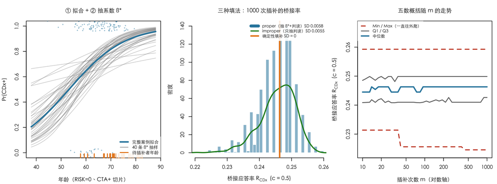

```r
set.seed(7)
d_one <- make_trial(); miss_one <- miss_mar(d_one)
M <- 1000; C_V <- c(1, 0.5, 0)
mi_pro <- draw_imp(d_one, miss_one, TRUE, M, C_V, "proper")
mi_imp <- draw_imp(d_one, miss_one, TRUE, M, C_V, "improper")
mi_det <- draw_imp(d_one, miss_one, TRUE,  20, C_V, "deterministic")

par(family = "cjk", mfrow = c(1, 3), mar = c(4.2, 4.2, 3.4, 0.8))

## (a) 抽系数：β* 曲线族
fit1 <- glm(CDx ~ AGE + RISK + CTA, data = d_one[!miss_one, ], family = binomial)
ag   <- seq(38, 88, length.out = 120)
Xg   <- cbind(1, ag, 0, 1)                                   # RISK=0、CTA=1 的切片
V    <- t(chol(summary(fit1)$cov.unscaled))
plot(NA, xlim = range(ag), ylim = c(0, 1), main = "① 拟合 + ② 抽系数 β*",
     xlab = "年龄（RISK=0、CTA+ 切片）", ylab = "Pr(CDx+)", cex.main = 1.1, cex.lab = 1.05)
for (k in 1:40)
  lines(ag, plogis(as.vector(Xg %*% (coef(fit1) + V %*% rnorm(4)))),
        col = adjustcolor("gray55", 0.45), lwd = 1)
lines(ag, plogis(as.vector(Xg %*% coef(fit1))), col = "#2E86AB", lwd = 3)
obs <- d_one[!miss_one & d_one$CTA == 1, ]
points(obs$AGE, jitter(obs$CDx, amount = 0.04), pch = 16, cex = 0.5,
       col = adjustcolor("#2E86AB", 0.5))
rug(d_one$AGE[miss_one], col = "#E8871E", lwd = 2, side = 1)
legend("bottomright", c("完整案例拟合", "40 条 β* 抽样", "待插补者年龄"),
       col = c("#2E86AB", "gray55", "#E8871E"), lwd = c(3, 1, 2), cex = 0.85,
       bg = adjustcolor("white", 0.88), box.col = NA)

## (b) 三种填法的跨插补散布
xr <- range(c(mi_pro[, "c0.5"], mi_imp[, "c0.5"], mi_det[, "c0.5"]))
hist(mi_pro[, "c0.5"], breaks = 30, col = adjustcolor("#2E86AB", 0.55), border = "white",
     freq = FALSE, xlim = xr, main = "三种填法：1000 次插补的桥接率",
     xlab = expression(paste("桥接应答率 ", R[CDx], "  (c = 0.5)")),
     ylab = "密度", cex.main = 1.1, cex.lab = 1.05)
lines(density(mi_imp[, "c0.5"]), col = "forestgreen", lwd = 2.4)
abline(v = mi_det[1, "c0.5"], col = "#E8871E", lwd = 3)
legend("topright", c(sprintf("proper（抽 β*+判读）SD %.4f", sd(mi_pro[, "c0.5"])),
                     sprintf("improper（只抽判读）SD %.4f", sd(mi_imp[, "c0.5"])),
                     "确定性填补 SD = 0"),
       col = c("#2E86AB", "forestgreen", "#E8871E"), lwd = c(6, 2.4, 3), cex = 0.8,
       bg = adjustcolor("white", 0.88), box.col = NA)

## (c) 五数概括随 m 漂移
ms <- unique(round(10^seq(log10(10), log10(M), length.out = 40)))
v  <- mi_pro[, "c0.5"]
fv <- t(vapply(ms, function(mm) c(min(v[1:mm]), quantile(v[1:mm], c(.25, .5, .75), names = FALSE),
                                  max(v[1:mm])), numeric(5)))
matplot(ms, fv, type = "l", log = "x", lty = c(2, 1, 1, 1, 2), lwd = c(2, 1.8, 2.6, 1.8, 2),
        col = c("#C73E1D", "gray45", "#2E86AB", "gray45", "#C73E1D"),
        ylim = range(fv) + c(-0.001, 0.008),          # 顶部留出 legend 的位置
        main = "五数概括随 m 的走势", xlab = "插补次数 m（对数轴）",
        ylab = expression(paste("桥接应答率 ", R[CDx], "  (c = 0.5)")),
        cex.main = 1.1, cex.lab = 1.05)
legend("topleft", c("Min / Max（一直往外爬）", "Q1 / Q3", "中位数"),
       col = c("#C73E1D", "gray45", "#2E86AB"), lty = c(2, 1, 1), lwd = c(2, 1.8, 2.6),
       cex = 0.8, bg = adjustcolor("white", 0.9), box.col = NA)
```

左图是”抽系数”这一步的样子：完整案例给一条拟合曲线（蓝），$\beta^{*}$ 每抽一次就换一条（灰）——灰带的宽度就是参数不确定性，待插补者（橙色刻度）的 $\pi_i$ 每轮都落在不同曲线上。

中图是三种填法的后果：proper 的散布最宽，improper 窄一点（这份数据上方差小 12%，缺失者更多、协变量更多时差距会更大），确定性填补是一根竖线——不确定性被抹成 0，多重插补名存实亡。

### 4.6.2 四种读数对撞

单次试验的差异会被抽样噪声吃掉（$n=150$ 时 PPA 的抽样标准差约 0.035，比要看的偏倚还大），所以重复 150 次试验、每次都和同一次试验的全数据估计配对相减，看平均偏倚：

```r
mi_rep <- function(mech, R = 150, m = 20, cf = 0.5) {
  keys <- c("PPA", "p", "R1", paste0("c", cf))
  t(vapply(seq_len(R), function(i) {
    d <- make_trial(); mi <- mech(d)
    full <- bridged_rate(d$CDx, d$CTA, d$RESP, cf)[keys]                     # 基准：没有缺失
    cc   <- bridged_rate(d$CDx[!mi], d$CTA[!mi], d$RESP[!mi], cf)[keys]      # 丢弃缺失者
    mx   <- colMeans(draw_imp(d, mi, FALSE, m, cf))[keys]                    # 插补：只用协变量
    mc   <- colMeans(draw_imp(d, mi, TRUE,  m, cf))[keys]                    # 插补：+CTA 判读
    c(rate = mean(mi[d$CTA == 1]), full = full, cc = cc - full,
      mx = mx - full, mc = mc - full)
  }, numeric(1 + 4*4)))
}
set.seed(11)
rep_mar  <- mi_rep(miss_mar)
rep_mnar <- mi_rep(miss_mnar)

bias_tbl <- function(res, cf = "c0.5") {
  g <- function(k) sapply(c("PPA", "p", "R1", cf), function(q) mean(res[, paste0(k, ".", q)]))
  se <- function(k) sd(res[, paste0(k, ".", cf)])/sqrt(nrow(res))
  data.frame(
    `做法` = c("丢弃缺失者（complete case）", "插补：仅协变量", "插补：协变量 + CTA 判读"),
    `ΔPPA` = sprintf("%+.4f", c(g("cc")[1], g("mx")[1], g("mc")[1])),
    `Δp`   = sprintf("%+.4f", c(g("cc")[2], g("mx")[2], g("mc")[2])),
    `ΔR_{1}` = sprintf("%+.4f", c(g("cc")[3], g("mx")[3], g("mc")[3])),
    `Δ桥接率 (c=0.5)` = sprintf("%+.5f", c(g("cc")[4], g("mx")[4], g("mc")[4])),
    `MC 标准误` = sprintf("%.5f", c(se("cc"), se("mx"), se("mc"))),
    check.names = FALSE)
}
ft_show(bias_tbl(rep_mar), title = "MAR 机制下的配对偏倚（150 次重复试验，每次 m = 20）",
        footers = sprintf(paste("基准 = 同一次试验的全数据估计：PPA %.4f、桥接率 %.4f；",
                                "平均缺失率 %.1f%%（入组 CTA+ 中）。Δ = 该做法 − 全数据。"),
                          mean(rep_mar[, "full.PPA"]), mean(rep_mar[, "full.c0.5"]),
                          100*mean(rep_mar[, "rate"])))
```

MAR 机制下的配对偏倚（150 次重复试验，每次 m = 20）

| 做法 | ΔPPA | Δp | ΔR1 | Δ桥接率 (c=0.5) | MC 标准误 |
| --- | --- | --- | --- | --- | --- |
| 丢弃缺失者（complete case） | -0.0204 | -0.0047 | -0.0032 | -0.00364 | 0.00149 |
| 插补：仅协变量 | -0.0208 | -0.0047 | -0.0020 | -0.00261 | 0.00056 |
| 插补：协变量 + CTA 判读 | +0.0009 | +0.0000 | -0.0024 | -0.00211 | 0.00048 |

基准 = 同一次试验的全数据估计：PPA 0.7523、桥接率 0.3030； 平均缺失率 16.6%（入组 CTA+ 中）。Δ = 该做法 − 全数据。

三行读下来：

- 丢弃缺失者确实偏：PPA 偏低约 0.020。缺失依赖年龄和风险层，而这两样又与真 marker 相关，所以剩下的人不是原样本的缩小版。
- 插补只用协变量，PPA 的偏倚几乎没修掉（-0.0208）：待插补者全是 CTA+，而模型是在”CTA+ 与外部阴性材料混在一起”的样本上拟合的，插出的判读因此偏阴。这正是前面说的保守方向。
- 把 CTA 判读放进模型，偏倚回到噪声量级（+0.0009）：这是 MAR 的正统做法。

最值得留意的是这四列之间的传递。 PPA 偏 0.020，经 Bayes 换成权重 $p$ 只剩 0.005，再乘 $(1-c)R_1$ 进桥接率——PPA 这一路对最终偏倚的贡献很小。写成一行链式导数就清楚了：

$$\frac{\partial
R_{CDx}}{\partial\,\text{PPA}}=\underbrace{(1-c)\,R_1}_{\text{结局那一路}}\times\underbrace{\frac{\partial
p}{\partial\,\text{PPA}}}_{\text{Bayes 那一路}},\qquad \frac{\partial
p}{\partial\,\text{PPA}}=\frac{prev\,(1-NPA)(1-prev)}{\bigl[\text{PPA}\cdot
prev+(1-NPA)(1-prev)\bigr]^{2}}$$

```r
b0 <- bridged_rate(d_one$CDx, d_one$CTA, d_one$RESP, 0.5)      # 这份数据的各量
dp_dppa <- PREV_CTA*(1 - b0[["NPA"]])*(1 - PREV_CTA) /
           (b0[["PPA"]]*PREV_CTA + (1 - b0[["NPA"]])*(1 - PREV_CTA))^2
slope <- (1 - 0.5)*b0[["R1"]] * dp_dppa
cat(sprintf("dp/dPPA = %.3f ;  (1-c)*R1 = %.3f ;  合起来 dR_CDx/dPPA = %.4f\n",
            dp_dppa, (1 - 0.5)*b0[["R1"]], slope))
```

```
## dp/dPPA = 0.203 ;  (1-c)*R1 = 0.140 ;  合起来 dR_CDx/dPPA = 0.0284
```

```r
w_R1 <- b0[["p"]] + (1 - b0[["p"]])*0.5                        # R1 那一路的系数
cat(sprintf("→ PPA 偏 %.3f 只搬来 %.4f；R1 偏 %.4f 搬来 %.4f；合计 %.4f，实测 %.4f\n",
            abs(mean(rep_mar[, "cc.PPA"])), abs(mean(rep_mar[, "cc.PPA"]))*slope,
            abs(mean(rep_mar[, "cc.R1"])),  abs(mean(rep_mar[, "cc.R1"]))*w_R1,
            abs(mean(rep_mar[, "cc.PPA"]))*slope + abs(mean(rep_mar[, "cc.R1"]))*w_R1,
            abs(mean(rep_mar[, "cc.c0.5"]))))
```

```
## → PPA 偏 0.020 只搬来 0.0006；R1 偏 0.0032 搬来 0.0028；合计 0.0034，实测 0.0036
```

两级衰减都在这条式子里：$p$ 是 PPA 的一个平缓函数（斜率 0.20），$(1-c)R_1$ 又把它再压一次（0.14），合起来把 PPA 的扰动缩到约 1/35。这条链天生对一致性的偏倚不敏感——所以这类敏感性分析常常得出”缺失带来的偏倚可忽略”，不是插补神奇，而是估计量的结构把这一路的扰动衰减掉了。

另一路没有这层保护。 $R_1$ 的系数是 $p+(1-p)c\approx0.89$——$R_1$ 偏多少，桥接率几乎照搬。上面那行输出把实测的桥接率偏倚 0.0036 拆开了：PPA 那一路只占 0.0006，其余来自 $R_1$。看一致性表判断”缺失影响大不大”会看错重点，真正要盯的是缺失有没有动 $R_1$（即有没有把系统性偏应答/偏不应答的人补进双阳格）。

### 4.6.3 汇总口径：五数概括 vs Rubin 规则

那 $m$ 个估计怎么变成一个结论？两种口径，回答的问题不同：

```r
set.seed(13)
m_r <- 200; B_r <- 200; n_one <- nrow(d_one)
th <- numeric(m_r); U <- numeric(m_r)
for (i in seq_len(m_r)) {
  cdx <- d_one$CDx; cdx[miss_one] <- impute_once(d_one, miss_one, TRUE, "proper")
  th[i] <- bridged_rate(cdx, d_one$CTA, d_one$RESP, 0.5)[["c0.5"]]     # 第 i 份的点估计
  U[i]  <- var(vapply(seq_len(B_r), function(b)                        # 第 i 份的组内方差
    bridged_rate(cdx, d_one$CTA, d_one$RESP, 0.5,
                 idx = sample.int(n_one, n_one, TRUE))[["c0.5"]], numeric(1)), na.rm = TRUE)
}
Wbar <- mean(U); Bv <- var(th); Tot <- Wbar + (1 + 1/m_r)*Bv           # Rubin 规则
ft_show(data.frame(
  `量` = c("θ̄（m 个估计的均值）", "W̄（组内方差：抽样不确定性）",
           "B（组间方差：插补不确定性）", "T = W̄ + (1+1/m)·B（总方差）",
           "缺失信息比例 FMI = (1+1/m)B / T", "Rubin 95% 区间", "五数概括的 Min–Max 跨度"),
  `值` = c(sprintf("%.4f", mean(th)), sprintf("%.3e", Wbar), sprintf("%.3e", Bv),
           sprintf("%.3e", Tot), sprintf("%.1f%%", 100*(1 + 1/m_r)*Bv/Tot),
           sprintf("[%.4f, %.4f]（宽 %.4f）", mean(th) - 1.96*sqrt(Tot),
                   mean(th) + 1.96*sqrt(Tot), 2*1.96*sqrt(Tot)),
           sprintf("[%.4f, %.4f]（宽 %.4f）", min(th), max(th), max(th) - min(th))),
  check.names = FALSE),
  title = "同一份数据的两种汇总：Rubin 规则 vs 五数概括",
  footers = sprintf("m = %d 次插补；每份插补数据集用 %d 次自助重抽算它自己的组内方差。", m_r, B_r))
```

同一份数据的两种汇总：Rubin 规则 vs 五数概括

| 量 | 值 |
| --- | --- |
| θ̄（m 个估计的均值） | 0.2450 |
| W̄（组内方差：抽样不确定性） | 1.336e-03 |
| B（组间方差：插补不确定性） | 3.462e-05 |
| T = W̄ + (1+1/m)·B（总方差） | 1.371e-03 |
| 缺失信息比例 FMI = (1+1/m)B / T | 2.5% |
| Rubin 95% 区间 | [0.1724, 0.3176]（宽 0.1451） |
| 五数概括的 Min–Max 跨度 | [0.2301, 0.2573]（宽 0.0272） |

m = 200 次插补；每份插补数据集用 200 次自助重抽算它自己的组内方差。

两者答的不是同一个问题。 $\bar W$ 是”这 150 个人本来就有的抽样不确定性”，$B$ 是”插补法引入的额外不确定性”；这里 $B$ 只占总方差的 2.5%。所以：

- 五数概括的跨度（宽 0.0272）只反映 $B$ 那一份。“跨插补的估计只在窄窄一段里晃”读作结论对缺失不敏感，是对的。
- 但它不是置信区间——Rubin 区间宽 0.1451，是它的 5.3 倍。要报不确定性，走 Rubin（或”先自助再插补”）；五数概括只当敏感性读。

### 4.6.4 当机制其实是 MNAR

把缺失改成还依赖判读本身（CDx− 更容易无效），同一套方法再跑一遍：

MNAR 机制下的配对偏倚（同样 150 次重复试验）

| 做法 | ΔPPA | Δp | ΔR1 | Δ桥接率 (c=0.5) | MC 标准误 |
| --- | --- | --- | --- | --- | --- |
| 丢弃缺失者（complete case） | +0.0542 | +0.0113 | +0.0014 | +0.00319 | 0.00089 |
| 插补：仅协变量 | +0.0343 | +0.0074 | -0.0056 | -0.00380 | 0.00061 |
| 插补：协变量 + CTA 判读 | +0.0593 | +0.0123 | -0.0088 | -0.00585 | 0.00070 |

缺失概率额外依赖 CDx 判读本身。基准 = 全数据估计：PPA 0.7537、 桥接率 0.3065；平均缺失率 13.4%。

PPA 这次偏高（缺的多是 CDx−，剩下的人阳性比例虚高），而且插补没有修掉它——正统做法（协变量 + CTA）的偏倚 +0.0593 和丢弃缺失者 +0.0542 一个量级。原因直白：插补模型是从观测到的那部分学关系的，而 MNAR 下这部分关系本身已经被筛过，学过来再套到缺失者身上，等于把偏倚照搬一遍。

桥接率那一列还出现了符号翻转（PPA 偏正、桥接率偏负）：插补进入三处，$R_1$ 那两处（分母、分子）把偏阴的、应答更少的人补进双阳格，压低了 $R_1$，方向与 $p$ 那一路相反。这正是前面说”净效应要算、不能凭一处推断”的实例。

要处理 MNAR，只能再加一个假设——例如给插补的 logit 加一个偏移量 $\Delta$、扫它的取值（$\delta$-adjustment / pattern-mixture）。那就又回到了第 3 步 $c$ 的位置上：一个数据说不出话的旋钮。

### 4.6.5 这一步能给什么、不能给什么

```r
# c=1 恒等式的自检：p 必须整个消掉，否则表格会与主分析的双阳应答率不一致。
chk <- bridged_rate(d_one$CDx, d_one$CTA, d_one$RESP, c(1, 0.5, 0))
stopifnot(isTRUE(all.equal(chk[["c1"]], chk[["R1"]])), chk[["c0"]] < chk[["c1"]])
cat(sprintf("✓ c=1 时桥接率 %.6f = 双阳应答率 R1 %.6f（p 消掉）；c=0 时降到 %.6f\n",
            chk[["c1"]], chk[["R1"]], chk[["c0"]]))
```

```
## ✓ c=1 时桥接率 0.280000 = 双阳应答率 R1 0.280000（p 消掉）；c=0 时降到 0.219754
```

能给：在 MAR 假设下，把”这些人若都有判读、结论会怎样”量出来，并给出结论对缺失的敏感度；顺带得到一个 $c=1$ 的交叉校验。

不能给：MAR 本身的检验（数据分不开 MAR 与 MNAR）；MNAR 下的无偏估计；以及——它替代不了把缺失率降下来（采样流程、复测机制）。第 3 步的 $c$ 和第 4 步的 MAR 是同一类东西的两个位置：统计能做的是把假设摆到明处、把它的后果算清楚，不是把假设消掉。

# 5 Follow-on：换一种缺失结构（一致性搬运）

bridging 讲完，换 follow-on——同一套骨架、又一种缺失结构。区别：bridging 自己试验里有疗效数据、只是人群错位；follow-on 连疗效试验都不做，药和 CCD 都已上市，新检测 FCD 只想证明”我和已批准的 CCD 判人足够一致”，从而间接继承 CCD 那套疗效证据。所以 follow-on 的主战场从”补疗效缺失格”变成”量一致性”——疗效那层用的正是地基里已讲的稀释事实。用外部 concordance study 支持 follow-on CDx 临床验证的统计框架可参见 Li (2016)。

## 5.1 follow-on 定位与一致性符号

问题：FCD 和 CCD 判人到底有多一致（follow-on 目标 1）？ 要回答它，先得有一把量”两个检测一致不一致”的尺子，并把符号定清楚。

承接 §1.3 的 follow-on 定位：要证 目标 1——FCD 与已批准 CCD 分类足够一致；目标 2——借 CCD 的疗效证据说明 FCD+ 人群疗效可接受（用地基里的疗效混合）。路径分直接（用 FCD 重做试验，或重测原 pivotal 样本）与间接（CCD 已确立疗效 + 外部 FCD-vs-CCD 一致性研究）。本章顺序：先把符号定清楚 → 一致性估计 + NI 检验（目标 1）→ 无参考的 $p_c$ 重加权 → 样本量 → 3-way 补充。

目标 2 里被”借”的量，正是地基里立过的 $\theta$——当时已和 $\eta$ 一起用模拟验证过三路对齐，这里正式派上用场，没有新符号：$\theta=PPV_c\,\delta_{\text{pos}}+(1{-}PPV_c)\,\delta_{\text{neg}}$，$PPV_c=\Pr(G{=}1\mid CCD{=}1)$——还是地基那两块积木，只是权重换成 CCD 的 PPV。$\theta$ 是 CCD 已经确立、可以借用的疗效；follow-on 的逻辑就是：若 FCD 与 CCD 判人足够一致（目标 1），则 $\eta\approx\theta$，于是 FCD+ 人群可继承 CCD 的疗效结论。（记号统一，地基也说过：$\mu$ 按真 $G$、$\eta$ 按 FCD、$\theta$ 按 CCD 索引疗效，三者都是同两块积木的混合，只是分组不同。）

先把符号定清楚。comparator CDx (CCD) 测两次（CCD1、CCD2）+ follow-on CDx (FCD)，可把”FCD-vs-CCD 一致性”和”CCD 自身重复一致性”做基准比较。

记号约定：每个检测的结果编码成 0/1——“= 1” 表示该检测把样本判为阳性（biomarker+），“= 0” 判为阴性。所以 $CCD1{=}1$ 是”第一次 CCD 判这个样本阳性”，$FCD{=}0$ 是”新检测判它阴性”。

PPA / NPA 是什么：两个检测对同一批样本的一致率。PPA（阳性一致率）= 一个检测判阳的样本里、另一个也判阳的比例，写成 $\Pr(\text{乙}{=}1\mid \text{甲}{=}1)$；NPA（阴性一致率）= 判阴里另一个也判阴的比例 $\Pr(\text{乙}{=}0\mid \text{甲}{=}0)$。数越大，两个检测越像。注意它们有方向性：交换条件检测与被比较检测，数值一般会变 (U.S. Food and Drug Administration 2007)。

下标读法：下标两个字母 = “以谁为参照 + 跟谁比”，其中 $C1$ = CCD1、$C2$ = CCD2、$F$ = FCD；第一个字母是参照（条件放在它上面），第二个是被比较的检测。于是：

- $C1F$：以 CCD1 为参照，看 FCD 与它多一致（$\Pr(FCD\mid CCD1)$）；
- $C2F$：以 CCD2 为参照，看 FCD；
- $C1C2$：以 CCD1 为参照，看 CCD2——这是 CCD 自己两次重复的一致，用作基准；
- $C2C1$：反过来，以 CCD2 为参照看 CCD1。

$$PPA_{C1F}=\Pr(FCD{=}1\mid
CCD1{=}1),\quad PPA_{C1C2}=\Pr(CCD2{=}1\mid CCD1{=}1)$$
$$NPA_{C1F}=\Pr(FCD{=}0\mid CCD1{=}0),\quad
NPA_{C1C2}=\Pr(CCD2{=}0\mid CCD1{=}0)$$
$$PPA_{C2F}=\Pr(FCD{=}1\mid CCD2{=}1),\quad
PPA_{C2C1}=\Pr(CCD1{=}1\mid CCD2{=}1)$$
$$NPA_{C2F}=\Pr(FCD{=}0\mid CCD2{=}0),\quad
NPA_{C2C1}=\Pr(CCD1{=}0\mid CCD2{=}0)$$

逻辑：FCD 相对 CCD（$C1F$、$C2F$）的一致性，不应明显差于 CCD 自己两次重复（$C1C2$、$C2C1$）。这就是 **NI**（非劣效性）式一致性检验的立意——拿”CCD 的重复性”当及格线。

正式写成四个单侧非劣效性假设（PPA、NPA 各两个，分别以 CCD1、CCD2 为参照）。每个 $\xi$ 是”CCD 自一致 − FCD-对-CCD 一致”的差距，$\delta_1$（PPA 侧）、$\delta_0$（NPA 侧）是可接受 margin：

$$H_0:\ \xi_{ppa1}=PPA_{C1C2}-PPA_{C1F}\
\ge\ \delta_1 \quad\text{vs}\quad H_a:\ \xi_{ppa1}<\delta_1$$
$$H_0:\ \xi_{ppa2}=PPA_{C2C1}-PPA_{C2F}\ \ge\
\delta_1 \quad\text{vs}\quad H_a:\ \xi_{ppa2}<\delta_1$$
$$H_0:\ \xi_{npa1}=NPA_{C1C2}-NPA_{C1F}\ \ge\
\delta_0 \quad\text{vs}\quad H_a:\ \xi_{npa1}<\delta_0$$
$$H_0:\ \xi_{npa2}=NPA_{C2C1}-NPA_{C2F}\ \ge\
\delta_0 \quad\text{vs}\quad H_a:\ \xi_{npa2}<\delta_0$$

差距落到 margin 之下（拒绝 $H_0$）= FCD 不比 CCD 自身重复性明显更差。

## 5.2 无参考标准：计数表、估计量与 $p_c$ 重加权

问题：现实里没有金标准（真 $G$ 看不到），而且入组还按 CCD1 富集过——这时候怎么估一致性才不被富集带偏？ 尤其是 CCD2 一侧的量，直接从富集样本里算会有系统性偏差。

先摆计数记号，再给 CCD1-条件化估计量，最后是富集下要的 $p_c$ 重加权。

计数表（符号记号）：

CCD1 × CCD2 × FCD 计数表（符号）

|  | CCD1+ CCD2+ | CCD1+ CCD2− | CCD1+ Total | CCD1− CCD2+ | CCD1− CCD2− | CCD1− Total |
| --- | --- | --- | --- | --- | --- | --- |
| FCD+ | a₁ | b₁ | m₁ | a₀ | b₀ | r₁ |
| FCD− | c₁ | d₁ | m₀ | c₀ | d₀ | r₀ |
| Total | n₁₁ | n₁₀ | n₁ | n₀₁ | n₀₀ | n₀ |

CCD1+ 分层内按 (CCD2, FCD) 记 $a_1,b_1,c_1,d_1$（行 = FCD、列 = CCD2），边缘计数：

$$m_1 = a_1 + b_1 \quad(\text{FCD+
数})$$
$$n_{11} = a_1 + c_1
\quad(\text{CCD2+ 数})$$
$$n_1 =
n_{11} + n_{10} \quad(\text{CCD1+ 总数})$$

CCD1− 分层内同理记 $a_0,b_0,c_0,d_0$，边缘计数：

$$r_0 = c_0 + d_0 \quad(\text{FCD−
数})$$
$$n_{00} = b_0 + d_0
\quad(\text{CCD2− 数}),\qquad n_0 = n_{01} + n_{00} \quad(\text{CCD1−
总数})$$

CCD1-条件化的估计量可直接从计数算，不受分层入组偏差影响，每个一行：

$$\hat{PPA}_{C1F}=m_1/n_1\quad(\text{CCD1+
里 FCD 也判阳的比例})$$
$$\hat{PPA}_{C1C2}=n_{11}/n_1\quad(\text{CCD1+ 里
CCD2 也判阳的比例})$$
$$\hat{NPA}_{C1F}=r_0/n_0\quad(\text{CCD1− 里 FCD
也判阴的比例})$$
$$\hat{NPA}_{C1C2}=n_{00}/n_0\quad(\text{CCD1− 里
CCD2 也判阴的比例})$$

富集入组（按 CCD1 抽）扭曲样本内 CCD1 分层比例。$p_c=\Pr(CCD1{=}1)$（真实人群 prevalence，非样本比例）重加权可还原 CCD2-条件化的四个量。用计数表的记号（$a,b,c,d$ 见上），四式为：

$$\hat{PPA}_{C2F}=\frac{p_c\,a_1
n_0+(1{-}p_c)a_0
n_1}{p_c(a_1{+}c_1)n_0+(1{-}p_c)(a_0{+}c_0)n_1}$$
$$\hat{PPA}_{C2C1}=\frac{p_c(a_1{+}c_1)n_0}{p_c(a_1{+}c_1)n_0+(1{-}p_c)(a_0{+}c_0)n_1}$$
$$\hat{NPA}_{C2F}=\frac{(1{-}p_c)d_0
n_1+p_c\,d_1 n_0}{(1{-}p_c)(b_0{+}d_0)n_1+p_c(b_1{+}d_1)n_0}$$
$$\hat{NPA}_{C2C1}=\frac{(1{-}p_c)(b_0{+}d_0)n_1}{(1{-}p_c)(b_0{+}d_0)n_1+p_c(b_1{+}d_1)n_0}$$

分子分母同除 $n_1 n_0$ 即看出：这四式都是用真实 CCD1 prevalence $p_c=\Pr(CCD1{=}1)$（来自外部流行病学数据或假设，不是样本里的比例）去重新加权两个 CCD1 分层内的样本比例——把富集扭曲的分层权重换回真实权重。下面用 worked example 把这四式与已知真值对撞，验证它们成立：

```r
pc <- assay_prev(TRUTH$assays$CCD)                              # p_c = Pr(CCD1=1)
tc_fcd  <- true_concordance(TRUTH$assays$CCD, TRUTH$assays$CDx) # FCD vs CCD 真值
tc_c2c1 <- true_concordance(TRUTH$assays$CCD, TRUTH$assays$CCD) # CCD 自重复真值
pool <- generate_population(3e5)
enr  <- rbind(pool[pool$CCD1==1,][1:2000,], pool[pool$CCD1==0,][1:2000,])   # 富集 1:1
e1 <- subset(enr, CCD1==1); e0 <- subset(enr, CCD1==0); n1 <- nrow(e1); n0 <- nrow(e0)
a1<-sum(e1$CDx==1&e1$CCD2==1); b1<-sum(e1$CDx==1&e1$CCD2==0); c1<-sum(e1$CDx==0&e1$CCD2==1); d1<-sum(e1$CDx==0&e1$CCD2==0)
a0<-sum(e0$CDx==1&e0$CCD2==1); b0<-sum(e0$CDx==1&e0$CCD2==0); c0<-sum(e0$CDx==0&e0$CCD2==1); d0<-sum(e0$CDx==0&e0$CCD2==0)
rw <- c(
  PPA_C2F  = (pc*a1*n0+(1-pc)*a0*n1)/(pc*(a1+c1)*n0+(1-pc)*(a0+c0)*n1),
  PPA_C2C1 = (pc*(a1+c1)*n0)/(pc*(a1+c1)*n0+(1-pc)*(a0+c0)*n1),
  NPA_C2F  = ((1-pc)*d0*n1+pc*d1*n0)/((1-pc)*(b0+d0)*n1+pc*(b1+d1)*n0),
  NPA_C2C1 = ((1-pc)*(b0+d0)*n1)/((1-pc)*(b0+d0)*n1+pc*(b1+d1)*n0))
naive <- c(
  PPA_C2F  = with(subset(enr, CCD2==1), mean(CDx==1)),
  PPA_C2C1 = with(subset(enr, CCD2==1), mean(CCD1==1)),
  NPA_C2F  = with(subset(enr, CCD2==0), mean(CDx==0)),
  NPA_C2C1 = with(subset(enr, CCD2==0), mean(CCD1==0)))
truth <- c(tc_fcd["PPA"], tc_c2c1["PPA"], tc_fcd["NPA"], tc_c2c1["NPA"])
ft_show(data.frame(
  `量` = c("PPA_{C2F}", "PPA_{C2C1}", "NPA_{C2F}", "NPA_{C2C1}"),
  `真值` = round(unname(truth),4),
  `naive（富集偏差）` = round(unname(naive),4),
  `p_{c} 重加权` = round(unname(rw),4),
  check.names = FALSE),
  title = "p_{c} 重加权（4 个 CCD2 条件化量）：naive 偏离、重加权贴回真值")
```

pc 重加权（4 个 CCD2 条件化量）：naive 偏离、重加权贴回真值

| 量 | 真值 | naive（富集偏差） | pc 重加权 |
| --- | --- | --- | --- |
| PPAC2F | 0.8309 | 0.8639 | 0.8050 |
| PPAC2C1 | 0.8162 | 0.8953 | 0.8017 |
| NPAC2F | 0.9319 | 0.9048 | 0.9306 |
| NPAC2C1 | 0.9131 | 0.8284 | 0.9108 |

## 5.3 worked：估计四量 + NI 检验

问题：FCD 到底够不够一致、够到能替代 CCD 吗？ 工具齐了，用一份代表性样本把四个一致性量估出来、对撞真值，再跑 NI 检验（判”FCD-对-CCD”不比”CCD 自身重复”差）：

```r
conc <- generate_population(1200)                              # 代表性一致性研究
c1pos <- subset(conc, CCD1 == 1); c1neg <- subset(conc, CCD1 == 0)
est <- c(mean(c1pos$CDx==1), mean(c1pos$CCD2==1),
         mean(c1neg$CDx==0), mean(c1neg$CCD2==0))
truth_conc <- c(true_concordance(TRUTH$assays$CCD, TRUTH$assays$CDx)[["PPA"]],
                true_concordance(TRUTH$assays$CCD, TRUTH$assays$CCD)[["PPA"]],
                true_concordance(TRUTH$assays$CCD, TRUTH$assays$CDx)[["NPA"]],
                true_concordance(TRUTH$assays$CCD, TRUTH$assays$CCD)[["NPA"]])
ft_show(data.frame(
  `一致性量` = c("PPA_{C1F}", "PPA_{C1C2}", "NPA_{C1F}", "NPA_{C1C2}"),
  `估计` = round(est, 4), `真值` = round(truth_conc, 4),
  check.names = FALSE),
  title = "一致性估计 vs 真值（CCD1 条件化）")
```

一致性估计 vs 真值（CCD1 条件化）

| 一致性量 | 估计 | 真值 |
| --- | --- | --- |
| PPAC1F | 0.8197 | 0.8309 |
| PPAC1C2 | 0.8388 | 0.8162 |
| NPAC1F | 0.9329 | 0.9319 |
| NPAC1C2 | 0.9209 | 0.9131 |

四个量的估计都逼近真值。按 §NI 假设框架跑检验，以 $\xi_{ppa1}$ 为代表（其余三个同套路，bootstrap 上界 $<\delta_1$ 则拒绝 $H_0$）：

```r
xi_boot <- boot_diff_paired(c1pos$CCD2==1, c1pos$CDx==1); delta1 <- 0.10
ft_show(round(c(xi_point = mean(c1pos$CCD2==1) - mean(c1pos$CDx==1),
  ci_upper_95 = unname(quantile(xi_boot, 0.95)), margin = delta1,
  reject_H0 = unname(quantile(xi_boot, 0.95) < delta1)), 4),
  title = "单侧 NI 检验（PPA）")
```

单侧 NI 检验（PPA）

| 量 | 值 |
| --- | --- |
| xi_point | 0.0191 |
| ci_upper_95 | 0.0492 |
| margin | 0.1000 |
| reject_H0 | 1.0000 |

✓ 估计逼近真值；FCD（最好的 assay）对 CCD 正确拒绝 $H_0$。

## 5.4 样本量 / power

问题：这个一致性研究要招多少人，才有足够把握（power）断定 FCD 合格？ 意向使用人群随机抽样可公式推导，但实际是非随机抽样（无闭式），用模拟：

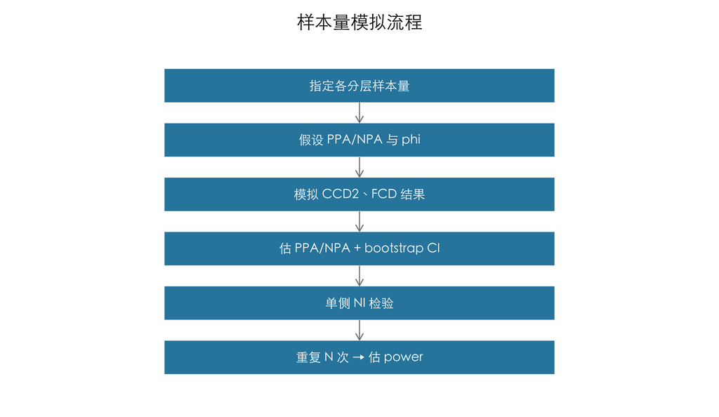

```r
par(family = "cjk", mar = c(0.5, 0.5, 3, 0.5))
plot(NA, xlim = c(0, 10), ylim = c(0, 7), axes = FALSE, xlab = "", ylab = "",
     main = "样本量模拟流程", cex.main = 1.5)
steps <- c("指定各分层样本量", "假设 PPA/NPA 与 phi", "模拟 CCD2、FCD 结果",
           "估 PPA/NPA + bootstrap CI", "单侧 NI 检验", "重复 N 次 → 估 power")
ys <- 6.4 - (seq_along(steps) - 1) * 1.12
for (i in seq_along(steps)) draw_box(5, ys[i], steps[i], "#2E86AB", w = 6.0, h = 0.72, cex = 1.05)
for (i in 1:(length(steps) - 1)) draw_arr(5, ys[i] - 0.36, 5, ys[i + 1] + 0.36)
```

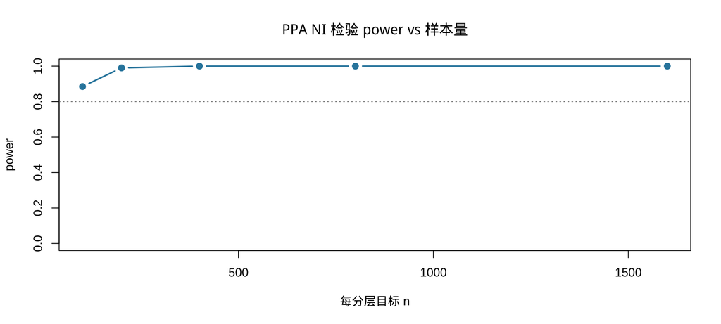

```r
power_at <- function(n_per, n_sim = 200, delta1 = 0.10, alpha = 0.05, B = 800) {
  rej <- logical(n_sim)
  for (s in seq_len(n_sim)) {
    d <- generate_population(2*n_per); cp <- subset(d, CCD1==1)
    if (nrow(cp) < 5) { rej[s] <- NA; next }
    rej[s] <- quantile(boot_diff_paired(cp$CCD2==1, cp$CDx==1, B = B), 1-alpha) < delta1
  }
  mean(rej, na.rm = TRUE)
}
n_grid <- c(100, 200, 400, 800, 1600); pw <- sapply(n_grid, power_at)
plot(n_grid, pw, type = "b", pch = 19, col = "#2E86AB", lwd = 2, ylim = c(0, 1),
     xlab = "每分层目标 n", ylab = "power", main = "PPA NI 检验 power vs 样本量")
abline(h = 0.8, lty = 3, col = "gray50")
```

## 5.5 补充：3-way 联合表与 phi

最后补一个 follow-on 一致性的技术点：给定 $G$ 条件独立，但 CCD1+ 分层内 FCD 与 CCD2 仍有残差正相关（CCD1+ 不能完全确定 $G$）。用 phi 量化，验证下面这个锚点 $P_{a1}=\varphi_1\sqrt{PPA_{C1C2}PPA_{C1F}(1{-}PPA_{C1C2})(1{-}PPA_{C1F})}+PPA_{C1C2}PPA_{C1F}$：

3-way 联合表（FCD 一次 + CCD 两次），用一致性量和两个锚点 $P_{a1},P_{d0}$ 参数化：

FCD × CCD1 × CCD2 联合概率表（Pa1、Pd0 为锚点）

|  | CCD1+/CCD2+ | CCD1+/CCD2- | CCD1-/CCD2+ | CCD1-/CCD2- |
| --- | --- | --- | --- | --- |
| FCD+ | Pa1 | PPAC1F − Pa1 | 1 − NPAC1C2 − NPAC1F + Pd0 | NPAC1C2 − Pd0 |
| FCD- | PPAC1C2 − Pa1 | 1 − PPAC1C2 − PPAC1F + Pa1 | NPAC1F − Pd0 | Pd0 |
| 合计 | PPAC1C2 | 1 − PPAC1C2 | 1 − NPAC1C2 | NPAC1C2 |

```r
a1p <- mean(c1pos$CCD2==1 & c1pos$CDx==1); pC2 <- mean(c1pos$CCD2==1); pF <- mean(c1pos$CDx==1)
phi1 <- (a1p - pC2*pF) / sqrt(pC2*(1-pC2)*pF*(1-pF))
ft_show(c(`φ_{1}` = round(phi1, 4), `P_{a1} 经验值` = round(a1p, 4),
  `P_{a1} 公式值` = round(phi1*sqrt(pC2*pF*(1-pC2)*(1-pF)) + pC2*pF, 4)),
  title = "φ 与锚点 P_{a1}：经验值 = 公式值")
```

φ 与锚点 Pa1：经验值 = 公式值

| 量 | 值 |
| --- | --- |
| φ1 | 0.5868 |
| Pa1 经验值 | 0.7705 |
| Pa1 公式值 | 0.7705 |

✓ 联合表公式自洽。phi>0 提醒：“给定 $G$ 条件独立” ≠ “分层内无关”——任何 follow-on 的样本量模拟都得带上这个 phi（见前面「样本量 / power」）。

# 6 综述与核验状态

统一结论：只要给对参数（真 $p$、真 $c$、正确权重），bridging / follow-on 机制能把被抽样偏差扭曲的疗效和一致性还原回 DGP 的已知真相。风险全在那几个不可识别的参数——$\delta_{01}$（缺失亚组疗效）、$c$、真实 prevalence——它们是假设出来的，不是估出来的。

bridging 与 follow-on：数据和方法论一模一样吗？ 不一样。一句话：底层生成机制一样，但观测到的数据不同，方法论共用一套骨架、估计对象却不同。 分维度对照：

bridging vs follow-on：同一类问题，不同缺失结构

| 维度 | bridging | follow-on |
| --- | --- | --- |
| 数据来源 | 药的 pivotal 试验本身 | 单独的一致性研究 + 已批准 CCD 的历史疗效 |
| 有无自带疗效数据 | 有（试验里 CTA+ 人群的 T、Y） | 无（FCD 上没有 T、Y） |
| 观测变量 | assay 结果 + 治疗臂 T + 结局 Y | 只有 assay 结果（CCD1/CCD2/FCD） |
| 缺失结构 | CTA−/CDx+ 那格没入组 → δ01 缺 | 富集抽样扭曲 CCD1 分层比例 + 无金标准 |
| 疗效从哪来 | 在自己试验里搬（CTA+ → CDx+） | 从 CCD 借（外推到 FCD+ 人群） |
| 核心公式 | δCDx = p·δ11 + (1−p)·δ01 | PPA/NPA 的 NI 检验 + pc 重加权 |
| 不可识别参数 | δ01（用敏感性参数 c 假设） | 真实 prevalence pc、分层内残差相关 φ |

共用的骨架：都是「assay 间 concordance + PPV 混合 + 一个不可识别参数」，把疗效/一致性从一个 assay 定义的人群搬到另一个。真正的分水岭是数据里有没有随机化疗效——bridging 有，只需搬运；follow-on 没有，只能借 CCD 的疗效并测自己与 CCD 的一致性。每加一层 assay 选择（多 CTA、pre-screening，见末章「进阶」），就多依赖一个猜测——这是反对多层 pre-screening 的根本原因。

> 提醒：本文 worked example 里两者共用同一个 DGP（同一批 $G$、assay、`TRUTH`），那是教学简化——好让”同一类问题”一眼可见、并能用同一套真值对撞验证；真实世界里两者的数据集并不相同（如上表）。

核验状态一览：各量三条路对齐 / 公式经真值验证成立

| 位置 | 结论 |
| --- | --- |
| § 混合疗效 η | ✓ 混合公式 = 直接估计 = 真值 |
| § NPA/PPA | ✓ NPA = d/(b+d) 直接从表读出 |
| § 贝叶斯 p | ✓ Bayes 估 p = 直接估计 |
| § 联合表参数化 | ✓ 边际自洽 (φ>0) |
| § pc 重加权 | ✓ pc 重加权还原真值 (pc = 真实 CCD1 prevalence) |
| § standard bridging | ✓ 真 c 处还原真 δCDx |
| § 第 4 步 MAR 插补 | ✓ 正统 MAR 插补（含 CTA 判读）回到全数据估计；只用协变量偏保守；MNAR 下修不掉 |
| § c=1 恒等式 | ✓ c=1 时 p 代数消掉，桥接率 = 双阳应答率（stopifnot 自检） |
| § double bridging | ✓ 全程限定 CDx+ 后还原真值 |
| § multi-CTA 一致性权重 | ✓ 按阳性/阴性人数加权，汇总一致性还原真值 |

*核验表最后两行（double bridging、multi-CTA）属末章「进阶」的两种额外情形。*

## 6.1 补充：为什么用连续端点（效应尺度与可塌缩性）

全文疗效统一用连续端点 $Y$ 的均值差 $\delta$，是一个刻意的选择。原因：贯穿全文的两条搬运恒等式——疗效混合 $\eta=PPV\,\delta_{\text{pos}}+(1{-}PPV)\,\delta_{\text{neg}}$、bridging 的 $\delta_{CDx}=p\,\delta_{11}+(1{-}p)\,\delta_{01}$——都是全期望，只有当 $\delta$ 是一个可塌缩 (collapsible) 的期望型量时才精确成立：均值差、某固定时点的生存概率差、或 **RMST**（restricted mean survival time，限制平均生存时间）差。

而现实肿瘤试验汇报疗效的通用货币是 Cox 模型给的 HR（hazard ratio）——HR 不可塌缩：两个亚组各自的 HR 按 $p$ 线性加权 $\neq$ 合并人群的 HR（风险比是比值不是期望，混合会系统性偏）。所以真实 bridging 里 $\delta_{11}$ 常常就是一个 HR，但线性混合不能直接架在 HR 上——要么换到可塌缩尺度（均值差 / 生存概率差 / RMST），要么放弃精确、做数值近似。

一句话：本文选连续端点是为了让搬运恒等式精确成立、教学干净；换成 HR 时，“看似能线性搬运、其实要挑对尺度”本身就是 bridging 会踩的坑。（具体某篇 bridging 方法论文用哪种尺度，以该文为准；Cox 的内部估计 partial likelihood 与本文主题无关，略。）

*调参入口：改「统一生成模型」里的 `TRUTH`（prevalence、各 assay sens/spec、marker+/− 真疗效），全文所有真值和估计会一致联动。*

# 7 进阶：额外的选择偏差层

标准 bridging 只有一个缺失亚组 (CTA−/CDx+)。两种情形引入更多：Case I pre-screening（双重 bridging）；Case II 多个 CTA。共同教训：每加一层 assay 选择，CDx 疗效估计离直接观测更远、不确定性更大。

## 7.1 Case I：Pre-Screening → Double Bridging

为加快入组/降成本，CTA 前加 biomarker 粗筛 (pre-screen)。多一个上游缺失：本该 CTA+ 却被粗筛排除的患者。

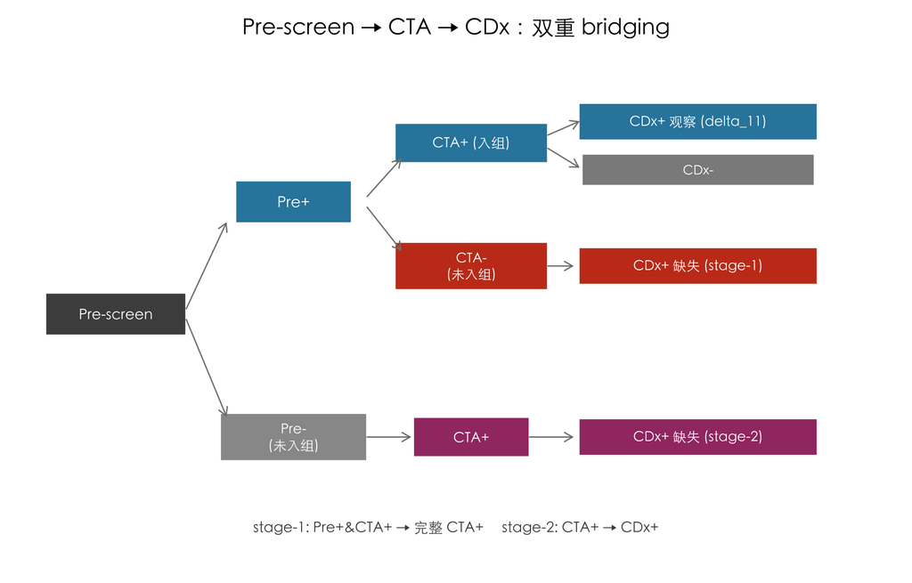

```r
par(family = "cjk", mar = c(0.5, 0.5, 3, 0.5))
plot(NA, xlim = c(0, 13.5), ylim = c(0, 9), axes = FALSE, xlab = "", ylab = "",
     main = "Pre-screen → CTA → CDx：双重 bridging", cex.main = 1.45)
draw_box(1.2, 4.5, "Pre-screen", "gray30", w = 2.3, h = 0.8, cex = 0.95)
draw_box(4.1, 6.6, "Pre+", "#2E86AB", w = 1.9, h = 0.8, cex = 1.0)
draw_box(4.1, 2.2, "Pre-\n(未入组)", "gray60", w = 2.4, h = 0.9, cex = 0.9)
draw_arr(2.35, 4.6, 3.0, 6.2); draw_arr(2.35, 4.4, 3.0, 2.6)
draw_box(7.0, 7.7, "CTA+ (入组)", "#2E86AB", w = 2.5, h = 0.75, cex = 0.92)
draw_box(7.0, 5.4, "CTA-\n(未入组)", "#C73E1D", w = 2.5, h = 0.9, cex = 0.88)
draw_arr(5.3, 6.7, 5.85, 7.4); draw_arr(5.3, 6.5, 5.85, 5.7)
draw_box(7.0, 2.2, "CTA+", "#A23B72", w = 1.9, h = 0.75, cex = 0.92)
draw_arr(5.3, 2.2, 6.0, 2.2)
draw_box(10.7, 8.1, "CDx+ 观察 (delta_11)", "#2E86AB", w = 3.9, h = 0.7, cex = 0.9)
draw_box(10.7, 7.2, "CDx-", "gray55", w = 3.8, h = 0.6, cex = 0.85)
draw_arr(8.25, 7.85, 8.75, 8.1); draw_arr(8.25, 7.6, 8.75, 7.25)
draw_box(10.7, 5.4, "CDx+ 缺失 (stage-1)", "#C73E1D", w = 3.9, h = 0.7, cex = 0.9)
draw_arr(8.25, 5.4, 8.65, 5.4)
draw_box(10.7, 2.2, "CDx+ 缺失 (stage-2)", "#A23B72", w = 3.9, h = 0.7, cex = 0.9)
draw_arr(7.95, 2.2, 8.65, 2.2)
text(6.75, 0.5, "stage-1: Pre+&CTA+ → 完整 CTA+     stage-2: CTA+ → CDx+",
     cex = 0.95, col = "gray30", font = 3)
```

调整变两阶段：Stage 1 从观测的 Pre+/CTA+ 还原完整 CTA+ 队列；Stage 2 从 CTA+ 还原 CDx+ 人群。

$$\delta_{CTA+}=(p_1+(1{-}p_1)c_1)\,\delta'_{11},\qquad
\delta_{CDx+}=(p+(1{-}p)c_2)\,\delta_{CTA+}$$

> 关键：两阶段所有子群都要先限定在 CDx+ 内，再按 Pre / CTA 细分。因为 estimand（$\delta_{CDx+}$）始终活在 CDx+ 人群里，$\delta'_{11}$ 指的是 (Pre+ & CTA+ & CDx+) 的疗效，不是整个 (Pre+ & CTA+) 的疗效——若不限定 CDx+，会用整个 CTA+ 的疗效冒充 CTA+&CDx+ 的疗效、系统性低估。下面严格限定 CDx+：

```r
big3 <- generate_population(4e6, with_endpoint = TRUE); cdxpos <- subset(big3, CDx == 1)
# stage 1: 在 CTA+&CDx+ 内按 Pre 还原
d11p <- delta_hat(subset(cdxpos, Pre==1 & CTA==1)); d01p <- delta_hat(subset(cdxpos, Pre==0 & CTA==1))
p1 <- mean(subset(cdxpos, CTA==1)$Pre == 1)
delta_CTApos_s1 <- p1*d11p + (1-p1)*d01p; true_d11c <- delta_hat(subset(cdxpos, CTA==1))
# stage 2: 在 CDx+ 内按 CTA 还原
p_true <- true_p_cta_given_cdx(); d01_s2 <- delta_hat(subset(cdxpos, CTA==0))
delta_CDx_s2 <- p_true*delta_CTApos_s1 + (1-p_true)*d01_s2
ft_show(data.frame(`p_{1}` = round(p1,4), `c_{1}` = round(d01p/d11p,4),
  `阶段1 还原` = round(delta_CTApos_s1,4), `阶段1 真值` = round(true_d11c,4),
  `阶段2 还原` = round(delta_CDx_s2,4), `δ_{CDx} 真值` = round(true_delta_in_assay_pos(TRUTH$assays$CDx),4),
  check.names = FALSE),
  title = "Double bridging：两阶段依次还原真值")
```

Double bridging：两阶段依次还原真值

| p1 | c1 | 阶段1 还原 | 阶段1 真值 | 阶段2 还原 | δCDx 真值 |
| --- | --- | --- | --- | --- | --- |
| 0.7942 | 0.9592 | 0.5928 | 0.5928 | 0.5494 | 0.5508 |

✓ 两阶段依次还原真值。每阶段一个缺口、一个敏感性参数——两阶段的双重收缩。变体：*部分 pre-screening*（只部分人群走粗筛，只有受影响子集需 double-bridging）、*患者层面 pre-screening 信息*（保留则能显式识别 Pre+/Pre− 分支，提高第一阶段透明度）。实践结论直白：尽量不用 pre-screening——它让最终 CDx 疗效估计更低更不精确。

## 7.2 Case II：多个 CTA

保险/site 偏好/国别监管导致多个 CTA，各自与 CDx 一致性不同、偏差程度不同。假设：每人只按一个 CTA 入组；各 CTA 患者选择表现类似。

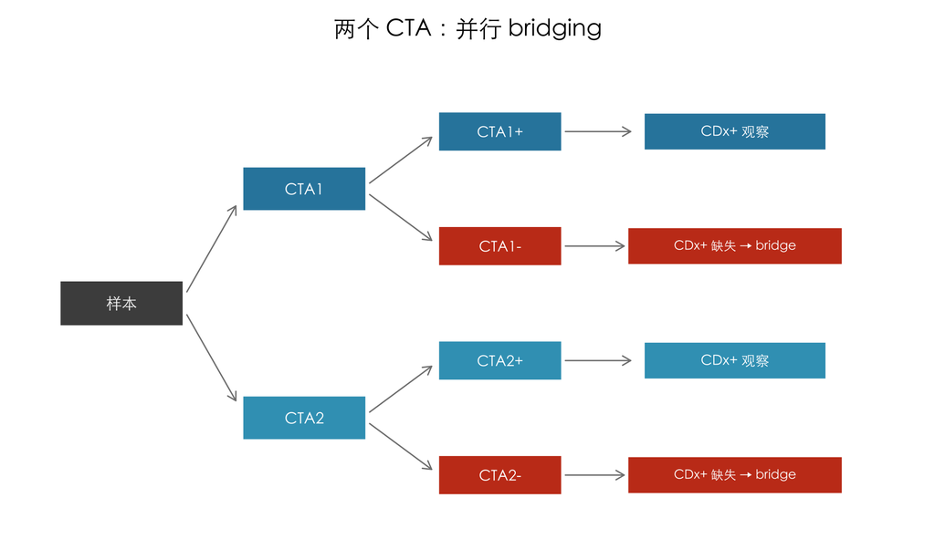

```r
par(family = "cjk", mar = c(0.5, 0.5, 3, 0.5))
plot(NA, xlim = c(0, 13), ylim = c(0, 8), axes = FALSE, xlab = "", ylab = "",
     main = "两个 CTA：并行 bridging", cex.main = 1.5)
draw_box(1.2, 4, "样本", "gray30", w = 1.9, h = 0.8, cex = 1.0)
draw_box(4.0, 6, "CTA1", "#2E86AB", w = 1.9, h = 0.78, cex = 1.0)
draw_box(4.0, 2, "CTA2", "#3AA0C0", w = 1.9, h = 0.78, cex = 1.0)
draw_arr(2.2, 4.2, 2.95, 5.7); draw_arr(2.2, 3.8, 2.95, 2.3)
draw_box(7.0, 7, "CTA1+", "#2E86AB", w = 1.9, h = 0.7, cex = 0.95); draw_box(7.0, 5, "CTA1-", "#C73E1D", w = 1.9, h = 0.7, cex = 0.95)
draw_arr(5.0, 6.1, 5.95, 6.9); draw_arr(5.0, 5.9, 5.95, 5.1)
draw_box(10.6, 7, "CDx+ 观察", "#2E86AB", w = 2.8, h = 0.66, cex = 0.9)
draw_box(10.6, 5, "CDx+ 缺失 → bridge", "#C73E1D", w = 3.3, h = 0.66, cex = 0.82)
draw_arr(8.0, 7, 9.0, 7); draw_arr(8.0, 5, 8.9, 5)
draw_box(7.0, 3, "CTA2+", "#3AA0C0", w = 1.9, h = 0.7, cex = 0.95); draw_box(7.0, 1, "CTA2-", "#C73E1D", w = 1.9, h = 0.7, cex = 0.95)
draw_arr(5.0, 2.1, 5.95, 2.9); draw_arr(5.0, 1.9, 5.95, 1.1)
draw_box(10.6, 3, "CDx+ 观察", "#3AA0C0", w = 2.8, h = 0.66, cex = 0.9)
draw_box(10.6, 1, "CDx+ 缺失 → bridge", "#C73E1D", w = 3.3, h = 0.66, cex = 0.82)
draw_arr(8.0, 3, 9.0, 3); draw_arr(8.0, 1, 8.9, 1)
```

方法 A（加权一致性）：先汇总 PPA/NPA/prevalence → 汇总 $p$ → 一次 bridging。 方法 B（加权疗效）：各 CTA 内分别 bridging → 按样本量合并。

```r
truth2 <- TRUTH
truth2$assays$CTA1 <- c(sens = 0.85, spec = 0.90)     # 阳性率约 0.33
truth2$assays$CTA2 <- c(sens = 0.90, spec = 0.50)     # 特异度差, 阳性率约 0.62 (强对比)
gen_cta <- function(n, oc) { d <- generate_population(n, truth = truth2, with_endpoint = TRUE)
  d$CTAx <- ifelse(d$G==1, rbinom(n,1,oc["sens"]), rbinom(n,1,1-oc["spec"])); d }
n1c <- 40000; n2c <- 40000; d1 <- gen_cta(n1c, truth2$assays$CTA1); d2 <- gen_cta(n2c, truth2$assays$CTA2)
bridge_one <- function(d, oc) {
  prev <- truth2$prev_G; ocd <- truth2$assays$CDx
  num <- sum(sapply(0:1, function(g){pc<-if(g==1)oc["sens"] else 1-oc["spec"]; pd<-if(g==1)ocd["sens"] else 1-ocd["spec"]; pc*pd*(if(g==1)prev else 1-prev)}))
  den <- sum(sapply(0:1, function(g){pd<-if(g==1)ocd["sens"] else 1-ocd["spec"]; pd*(if(g==1)prev else 1-prev)}))
  p <- num/den
  p*delta_hat(subset(d, CTAx==1 & CDx==1)) + (1-p)*delta_hat(subset(d, CTAx==0 & CDx==1))
}
dB1 <- bridge_one(d1, truth2$assays$CTA1); dB2 <- bridge_one(d2, truth2$assays$CTA2)
ft_show(data.frame(`方法 B（加权疗效）` = round(dB1*n1c/(n1c+n2c) + dB2*n2c/(n1c+n2c), 4),
           `δ_{CDx} 真值` = round(true_delta_in_assay_pos(truth2$assays$CDx, truth2), 4),
           check.names = FALSE),
        title = "多 CTA 方法 B（加权疗效）还原真值")
```

多 CTA 方法 B（加权疗效）还原真值

| 方法 B（加权疗效） | δCDx 真值 |
| --- | --- |
| 0.5557 | 0.5508 |

汇总一致性的加权（一个易错点）：跨 CTA 汇总 PPA/NPA 时，PPA 要按各队列的 CTA 阳性人数加权、NPA 按阴性人数加权，不能按总样本量 $n_i/n$——因为 PPA 是”阳性里判阳的比例”，权重自然是阳性人数。下面对比两种权重：

```r
ppa1 <- true_concordance(truth2$assays$CTA1, truth2$assays$CDx)["PPA"]
ppa2 <- true_concordance(truth2$assays$CTA2, truth2$assays$CDx)["PPA"]
pos1 <- sum(d1$CTAx==1); pos2 <- sum(d2$CTAx==1)
ft_show(data.frame(`按阳性人数（对）` = round(unname((pos1*ppa1+pos2*ppa2)/(pos1+pos2)), 4),
           `按总样本量（错）` = round(unname(ppa1*n1c/(n1c+n2c) + ppa2*n2c/(n1c+n2c)), 4),
           check.names = FALSE),
        title = "汇总一致性：按阳性人数 vs 按总样本量")
```

汇总一致性：按阳性人数 vs 按总样本量

| 按阳性人数（对） | 按总样本量（错） |
| --- | --- |
| 0.5454 | 0.5951 |

✓ 方法 B 还原真值；汇总一致性按阳性人数加权得到正确值，按总样本量加权则明显偏离。（注意区分：方法 B 最后按 $n_i/n$ 合并疗效是另一回事——那是”各 CTA 使用份额”的建模选择、需业务判断，不是这里的加权问题。）

# 8 记号表（希腊字母与关键符号）

查阅用。$\delta_{\text{pos}}/\delta_{\text{neg}}$ 是本文为”两块积木”起的简写（等价于两个 $\mu$ 相减）。

记号表（希腊字母与关键符号）

| 符号 | 定义 | 备注 |
| --- | --- | --- |
| T | 治疗臂 =1 / 对照臂 =0 |  |
| G | 真实 marker 状态：1 阳 / 0 阴 | 需参考标准才可观测 |
| μTG | 结局均值，按 (治疗臂 T, 真 marker G) 索引的四格 | 最底层原料 |
| δpos = μ11 − μ01 | 真 marker+ 人群的治疗效应（积木一） | 本文简写 |
| δneg = μ10 − μ00 | 真 marker− 人群的治疗效应（积木二） | 本文简写 |
| η | FCD+ 人群疗效 = PPVf·δpos + (1−PPVf)·δneg | 按 FCD 索引 |
| θ | CCD+ 人群疗效 = PPVc·δpos + (1−PPVc)·δneg | 按 CCD 索引；follow-on 借用的量 |
| δCDx | CDx+ 人群疗效（bridging 估计目标） |  |
| δ11, δ01 | (CTA+ & CDx+) / (CTA− & CDx+) 人群疗效 | 观察到 / 缺失 |
| δ'11, δ'01, δCTA+ | double bridging 第一阶段：(Pre± & CTA+ & CDx+) 疗效、还原出的 CTA+ 队列疗效 | 进阶 |
| c, c1, c2 | 敏感性参数：δ01 = c·δ11（及两阶段版本），c ∈ (0,1) | 缺失格不可识别 |
| p | Pr(CTA+ \| CDx+)——bridging 搬运权重 |  |
| p1 | Pr(Pre+ \| CTA+)——double bridging 第一阶段权重 | 进阶 |
| pc | Pr(CCD1=1)——真实人群 CCD1 prevalence（重加权用） | 非样本比例 |
| prev, π | Pr(CTA+)——意向使用人群的 marker prevalence | Bayes 估 p 用 |
| PPVf, NPVf | FCD 的阳性/阴性预测值 Pr(G=1\|FCD=1)、Pr(G=0\|FCD=0) |  |
| PPVc, NPVc | CCD 的阳性/阴性预测值（同构定义，assay 换成 CCD） |  |
| PPA, NPA, OPA | 阳性/阴性/总体一致率（OPA=(a+d)/n 判读完全一致的比例，本文只列不用）；下标两字母 = 参照 + 被比（C1=CCD1、C2=CCD2、F=FCD） |  |
| ξppa1, … | NI 检验的差距，如 ξppa1 = PPAC1C2 − PPAC1F |  |
| δ1, δ0 | NI 检验 PPA 侧 / NPA 侧的可接受 margin | 与疗效 δ 无关，是检验边界 |
| φ1, φ2 | φ 系数：CCD1+ / CCD1− 分层内 FCD 与 CCD2 的相关 |  |
| Pa1, Pd0 | 3-way 联合表的两个概率锚点 |  |
| R1, R2, RCDx | 率版本的疗效：观察格 (CTA+ & CDx+) 应答率、缺失格应答率 (=c·R1)、桥接后 CDx+ 人群应答率 | 与 δ 版本同构，公式不变 |
| R（缺失指示） | 缺失指示：R=1 表示该个体的 CDx 判读缺失（第 4 步用） | 测量层缺失 |
| X, Z | X = 观测协变量（插补模型的自变量）；Z = 待插补的 CDx 判读 | MAR 定义里的两个角色 |
| m, β* | m = 插补次数；β* = 从 Cov(β̂) 抽出的一套系数（插补的第二次抽样） | 插补内部 |
| W̄, B, T, FMI | Rubin 规则：组内方差均值、组间方差、总方差 T = W̄+(1+1/m)B、缺失信息比例 | 汇总口径：五数概括只含 B 那一份 |

（完整框架里还有按 FCD 索引的分量 $\eta_{11},\eta_{01},\dots$ 和按 CCD 索引的 $\theta_{11},\theta_{01},\dots$——本文只用它们的差 $\eta=\eta_{11}-\eta_{01}$、$\theta=\theta_{11}-\theta_{01}$，分量本身不必单独记。）

# 9 统计缩写速查

统计缩写速查

| 缩写 | 英文全称 | 中文含义 | 用在本文哪里 |
| --- | --- | --- | --- |
| PPA / NPA / OPA | positive / negative / overall percent agreement | 阳性/阴性/总体一致率 | assay 间一致性评价（OPA 仅列出、不用） |
| PPV / NPV | positive / negative predictive value | 阳性/阴性预测值 | assay+ 人群疗效混合 |
| NI | non-inferiority | 非劣效性 | FCD 相对 CCD 的一致性检验 |
| CI | confidence interval | 置信区间 | 一致性估计的不确定性 |
| RCT | randomized controlled trial | 随机对照试验 | 试验设计语境 |
| MI | multiple imputation | 多重插补 | 第 4 步：缺失 CDx 判读的插补 |
| MCAR / MAR / MNAR | missing completely at random / at random / not at random | 完全随机缺失 / 随机缺失 / 非随机缺失 | 第 4 步：缺失机制三档 |
| FMI | fraction of missing information | 缺失信息比例 | Rubin 规则里插补方差占总方差的比例 |

# 10 参考文献

Li, Meijuan. 2016. “Statistical Methods for Clinical Validation of Follow-on Companion Diagnostic Devices via an External Concordance Study.” *Statistics in Biopharmaceutical Research* 8 (3): 355–63. https://doi.org/10.1080/19466315.2016.1202859.

Little, Roderick J. A., and Donald B. Rubin. 2019. *Statistical Analysis with Missing Data*. 3rd ed. John Wiley & Sons. https://doi.org/10.1002/9781119482260.

National Research Council. 2010. *The Prevention and Treatment of Missing Data in Clinical Trials*. The National Academies Press. https://doi.org/10.17226/12955.

Rubin, Donald B. 1987. *Multiple Imputation for Nonresponse in Surveys*. John Wiley & Sons. https://doi.org/10.1002/9780470316696.

Song, Changhong, Xiaoqin Xiong, Sunghee Kim, Zhiheng Xu, Dandan Xu, and Bipasa Biswas. 2024. “Statistical Considerations for Some Issues in Clinical Bridging Studies Evaluating Companion Diagnostic Devices.” *Journal of Biopharmaceutical Statistics* 34 (3): 441–52. https://doi.org/10.1080/10543406.2023.2220398.

U.S. Food and Drug Administration. 2007. *Statistical Guidance on Reporting Results from Studies Evaluating Diagnostic Tests: Guidance for Industry and FDA Staff*. U.S. Department of Health; Human Services, Food; Drug Administration. https://www.fda.gov/media/71147/download.

U.S. Food and Drug Administration. 2014. *In Vitro Companion Diagnostic Devices: Guidance for Industry and Food and Drug Administration Staff*. U.S. Department of Health; Human Services, Food; Drug Administration. https://www.fda.gov/media/81309/download.

U.S. Food and Drug Administration. 2016. *Principles for Codevelopment of an in Vitro Companion Diagnostic Device with a Therapeutic Product: Draft Guidance for Industry and Food and Drug Administration Staff*. U.S. Department of Health; Human Services, Food; Drug Administration. https://www.fda.gov/media/99030/download.

*作者：胡杨博士 ｜ 首次发布：2026-08-25 ｜ 最后更新：2026-09-28 16:39 EDT*